# Managing the risks and side effects of workplace friendships: The moderating role of workplace friendship self-efficacy - ScienceDirect

- [View **PDF**](https://www-sciencedirect-com.ezproxy.spu.edu/science/article/pii/S0001879123000350/pdfft?md5=31dbfb7bfdbbe48b336186b4663399da&pid=1-s2.0-S0001879123000350-main.pdf)

## [Journal of Vocational Behavior](https://www-sciencedirect-com.ezproxy.spu.edu/journal/journal-of-vocational-behavior)

[Volume 143](https://www-sciencedirect-com.ezproxy.spu.edu/journal/journal-of-vocational-behavior/vol/143/suppl/C), June 2023, 103875

# Managing the risks and side effects of workplace friendships: The moderating role of workplace friendship self-efficacy

[https://doi.org/10.1016/j.jvb.2023.103875](https://doi-org.ezproxy.spu.edu/10.1016/j.jvb.2023.103875)[Get rights and content](https://s100.copyright.com/AppDispatchServlet?publisherName=ELS&contentID=S0001879123000350&orderBeanReset=true)

Under a Creative Commons [license](http://creativecommons.org/licenses/by-nc-nd/4.0/)

open access

## Highlights

- •

  Workplace friendships can lead to incivility at work.
- •

  Employees instigated incivility toward other coworkers rather than their workplace friends.
- •

  Inter-role conflict and resource depletion explain these detrimental effects.
- •

  Employees with higher workplace friendship self-efficacy seem better able to manage these detrimental effects

## Abstract

In this paper, we investigate the risks and side effects of workplace friendships for coworkers. Combining the dialectical perspective on workplace friendships with a self-regulatory perspective, we argue that workplace friendships can lead to incivility directed toward coworkers because employees experience inter-role conflict between their role as “employee” and their role as “friend”, and subsequent resource depletion. We further suggest that employees with higher workplace friendship self-efficacy are better able to manage these risks and side effects. We tested our hypotheses in two studies with time-lagged data (Study 1: 451 employees, Study 2: 499 employees) using structural equation modeling. Study 1 showed that workplace friendships are positively related to incivility via inter-role conflict and subsequent resource depletion. Workplace friendship self-efficacy buffered the indirect relation between workplace friendships and incivility. Study 2 partly replicated and extended the findings from Study 1. We found support for the serial mediation effect of workplace friendship on incivility via inter-role conflict and resource depletion and we were able to extend Study 1 by disentangling the targets of incivility. In particular, employees instigated incivility toward other coworkers rather than their workplace friends. However, the moderating effect of workplace friendship self-efficacy did not replicate. Our findings contribute to the literatures on workplace friendships and role conflicts.

## Keywords

Workplace friendships

Role theory

Role conflict

Resource depletion

Self-efficacy

*Workplace friendships* refer to voluntary and informal social relationships at work that are driven by communal norms and socioemotional goals (Pillemer & Rothbard, 2018). As an important aspect of organizational life, workplace friendships can provide employees with a sense of belonging at work (Dutton & Heaphy, 2003; Methot et al., 2017). Accordingly, the majority of studies documented the benefits of workplace friendships, such as increased employee well-being (Hsu et al., 2019; Morrison, 2004; Nielsen et al., 2000; Zhang et al., 2021), boosts in cooperation, creativity, and workplace innovation (Jehn & Shah, 1997; Lu et al., 2017), and more effective organizational functioning (Berman et al., 2002). For a while, scholars have therefore viewed workplace friendship through “rose‑tinted glasses” assuming workplace friendship to be an almost exclusively positive phenomenon.

Recently however, scholars have started to question this exclusively positive perspective of workplace friendships (Hommelhoff, 2019; Ingram & Zou, 2008; Methot et al., 2016; Pillemer & Rothbard, 2018). Workplaces are grounded in norms and expectations of instrumentality and impartiality, whereas friendships are based on norms of affection and favoritism (Bridge & Baxter, 1992; Hommelhoff, 2019; Ingram & Zou, 2008). These conflicting norms and expectations can become an excessive demand for employees involved in workplace friendships (Dietz & Fasbender, 2022). Employees may feel overwhelmed because they cannot reconcile the norms and expectations of their role as “employee” and their role as “friend” and react with deviant work behavior toward coworkers, such as *incivility* (i.e., insensitive, rude, and discourteous behavior toward others; Andersson & Pearson, 1999). Incivility occurs more frequently than high-intensity deviant work behaviors (e.g., aggression or violence; Schilpzand et al., 2016) and can have serious detrimental consequences for organizations, such as lower levels of innovative and creative performance (Sharifirad, 2016; Zhan et al., 2019), or higher levels of absenteeism and employee turnover (Cortina et al., 2013; Porath & Pearson, 2012). It is therefore worth investigating the potential link between workplace friendships and incivility due to role tensions and consider ways of managing this unwanted side effect.

While research on the risks and side effects of workplace friendships has gained traction (Hommelhoff, 2019; Methot et al., 2016; Pillemer & Rothbard, 2018), our understanding of the outcomes, associated mechanisms, and boundary conditions is incomplete. Researchers have conceptualized negative effects for individuals (e.g., distraction from individual goals), groups (i.e., ineffective decision-making), and organizations (inhibited information sharing; Pillemer & Rothbard, 2018), but negative effects have only been empiricially demonstrated for individual task performance (Methot et al., 2016). We have yet to understand the potential negative spill-over effects for coworkers. Understanding how coworkers are affected is important as it broadens our understanding of the implications of workplace friendships as a relational phenomenon. Focusing on deviant work behavior directed toward coworkers seems particularly relevant as research outside of the workplace suggests that friendships can stimulate risky, norm-deviant, and antisocial behavior (Bagwell, 2004; Ciairano et al., 2007). Shedding light on potential harm for coworkers is relevant to allow for more comprehensive theorizing and overcome possible risks and side effects.

Further, the underlying mechanisms of the link between workplace friendships and deviant work behavior directed at coworkers have yet to be deciphered. More specifically, researchers conceptualized role tensions between the norms and expectations of the employee role and the friend role (Bridge & Baxter, 1992; Pillemer & Rothbard, 2018) and explored broken friendship rules and conflicting resources in a critical incident study (Hommelhoff, 2019). In addition, they demonstrated that depleted resources in terms of exhaustion can explain the negative effects of workplace friendships on individual task performance (Methot et al., 2016). However, these role and resource-based perspectives have yet to be integrated to understand the precise nature of the underlying processes that link workplace friendships to negative interpersonal outcomes such as deviant work behavior.

It is also important to shed light on the boundary conditions that can buffer the risks and side effects of workplace friendships. Specifically, understanding how individual characteristics shape the resource depleting pathway allows for a more nuanced theorizing and interventions regarding the negative effects of workplace friendships (Methot et al., 2016). In addition, theorizing and testing individual characteristics as moderators also complement conceptual research that only highlighted friendship characteristics (e.g., closeness, status inequality) as potential boundary conditions (Bridge & Baxter, 1992; Pillemer & Rothbard, 2018).

In this research, we therefore examine the mechanisms through which workplace friendships can spark incivility directed toward coworkers, and we uncover the moderating role of workplace friendship self-efficacy. Combining the dialectical perspective on workplace friendships (Bridge & Baxter, 1992) with a self-regulatory perspective (Beal et al., 2005), we argue that workplace friendships can lead to incivility directed toward coworkers because employees experience *inter-role conflict* (i.e., overall tension or conflict between the “employee” role and the “friend” role also called dual-role tensions; Bridge & Baxter, 1992) and subsequent *resource depletion* (i.e., a mental state associated with the feeling that one's resources and energy levels are running low; Lanaj et al., 2014). Accordingly, workplace friendships can deplete employees' resources because they are struggling to reconcile the conflicting demands associated with the enactment of employee and friend roles at work. As a result of the experience of resource scarcity, employees may fail to regulate their behavior in line with workplace norms (Christian & Ellis, 2011; Rosen et al., 2016) and thus engage more in insensitive, rude, and discourteous behavior toward others. However, we further argue that employees with higher *workplace friendship self-efficacy* (Bagci et al., 2019; Fitzpatrick & Bussey, 2014), which represents a context-specific form of general self-efficacy (i.e., confidence in one's ability; Bandura, 1977), are better able to manage the simultaneous demands of employee and friend roles. Employees who are more confident in their ability to manage their workplace friendships are better able to navigate the tensions between the conflicting demands of their roles as employee and friend, such that the detrimental [downstream consequences](https://www-sciencedirect-com.ezproxy.spu.edu/topics/psychology/downstream-consequence) of workplace friendships on incivility should be buffered.

With this research, we aim to contribute to the literatures on workplace friendships, role conflicts, and workplace incivility. First, we contribute to the nascent but growing research stream on the risks and side effects of workplace friendships (Hommelhoff, 2019; Methot et al., 2016; Pillemer & Rothbard, 2018) by specifying that not only the focal employee but also coworkers can be affected negatively. Specifically, we examine incivility directed toward coworkers who may or may not be part of the focal workplace friendship as an outcome. In doing so, we broaden extant theorizing about who can be negatively affected by workplace friendships, which has conceptualized downsides for focal employees, groups, and organizations (Pillemer & Rothbard, 2018). With our research, we add coworkers—who may or may not be part of the focal workplace friendship—to the list of targets that might experience negative consequences.

Second, we shed light on the processes through which workplace friendships are linked to detrimental interpersonal outcomes such as incivility. Focusing on the consequences of the conflict between the formal employee role and the informal friend role contributes to research on role conflict in the work context more broadly. This research has either focused on conflicts between different aspects of the employee role (e.g., multi-team membership; Berger & Bruch, 2021) or examined conflicts between work and family roles (e.g., work-family conflict; Kossek & Lee, 2017). We draw on the dialectical perspective of workplace friendships to add the conflict between employee and friend roles at work to this research stream. We further integrate a role-based perspective (i.e., dialectical perspective on workplace friendships; Bridge & Baxter, 1992) with a self-regulatory perspective (Beal et al., 2005), to allow for more precise specification of the sequential process that links workplace friendships to detrimental interpersonal outcomes.

Third, with our investigation of workplace friendships as an unanticipated precursor of incivility, we also contribute to our understanding of the antecedents of incivility. Specifically, we add a relational perspective to the literature, which has so far concentrated on attitudes and characteristics of the instigator (e.g., job satisfaction, Blau & Andersson, 2005; trait anger, Meier & Semmer, 2013; machiavellianism, Lata & Chaudhary, 2020) or situational antecedents of incivility (e.g., job demands, van Jaarsveld et al., 2010). Given that the workplace is a hub for social interactions between coworkers, a better understanding of relational aspects leading to incivility matters. Despite the positive outcomes of workplace friendships, it is important to understand how it may harm others through incivility directed toward coworkers, and detect ways to minimize the [downstream consequences](https://www-sciencedirect-com.ezproxy.spu.edu/topics/psychology/downstream-consequence) on incivility (Schilpzand et al., 2016). In this regard, we introduce workplace friendship self-efficacy as a potential moderator of the unwanted effects of workplace friendships, which adds an agentic perspective to research on boundary conditions of workplace friendships' effects on incivility toward involved or non-involved coworkers.

## 1. Theoretical background

The dialectical perspective on workplace friendships (Bridge & Baxter, 1992) provides a useful theoretical lens to understand the risks and side effects of workplace friendships as it highlights the specific tensions between the “employee” and “friend” roles at work. Bridge and Baxter (1992) apply dialectical perspectives on romantic and non-work friendship relationships (Baxter, 1988; Rawlins, 1989) to the work context, to specify why blending the informal friendship role with the formal employee role leads to inter-role conflict (Kahn et al., 1964; Katz and Kahn, 1978). Accordingly, role demands grounded in norms and expectations associated with the employee and the friend roles might be incompatible and even contradictory, thereby creating dialectical tensions (i.e., a contradiction of functional opposites that negate each other; Bridge & Baxter, 1992).

More specifically, an employee might experience inter-role conflict because their role as employee requires them to act impartial and treat everyone at work equally, whereas their role as friend requires them to display preferential treatment toward their workplace friends (i.e., impartiality-favoritism dialectic; Bridge & Baxter, 1992). In addition, workplace friendships might lead to inter-role conflict because friendship norms of total acceptance might collide with work-related expectations of using judgment and criticism to improve work outcomes (i.e., judgment-acceptance dialectic; Bridge & Baxter, 1992). Further, workplace friendships might be associated with inter-role conflict because expectations of maintaining personal connections with workplace friends might challenge an employee's autonomy (i.e., autonomy-connection dialectic; Bridge & Baxter, 1992). Moreover, expectations of being totally equal as friends might collide with inequality built into different employee roles regarding seniority, responsibility, and remuneration (i.e., equality-inequality dialectic; Bridge & Baxter, 1992). Finally, expectations of total openness and confidentiality with friends might contradict expectations of workplace information management where relevant information needs to be shared and some information needs to be kept confidential (i.e., openness-closedness dialectic; Bridge & Baxter, 1992).

In turn, inter-role conflict can lead to resource depletion (Kahn et al., 1964; Ritter et al., 2016; Rizzo et al., 1970) because employees attempt to regulate their behavior to adapt to highly demanding work situations. The initial loss of resources and the subsequent attempt to cope with the demands by investing more resources deplete employees' reservoir of self-regulatory resources and thus inhibit further self-regulatory processes (Beal et al., 2005). When employees experience resource depletion, they lack the necessary self-regulatory resources to control impulses and inhibit socially undesirable behaviors (Eissa & Wyland, 2018; Liu et al., 2015; Wheeler et al., 2013). This self-regulation impairment resulting from resource depletion can give rise to behavior that is inconsistent with personal goals and workplace norms (Christian & Ellis, 2011; Rosen et al., 2016), such as abuse (Wheeler et al., 2013), aggression (Liu et al., 2015), and social undermining (Eissa & Wyland, 2018).

From a dialectical perspective on workplace friendships, we further argue that the risks and side effects of workplace friendships are shaped by individual characteristics. One individual characteristic, which is promising in buffering the potential risks and side effects, is workplace friendship self-efficacy. Workplace friendship self-efficacy reflects one's confidence in managing personal relationships at work (Bagci et al., 2019; Fitzpatrick & Bussey, 2014). Self-efficacious employees hold relevant mastery experiences that can help them to meet the demands and expectations of their multiple work roles (Bandura, 1977). As a result, self-efficacious employees should be less prone to the risks and side effects of workplace friendships. We therefore consider workplace friendship self-efficacy as a relevant boundary condition. Fig. 1 shows our conceptual model.

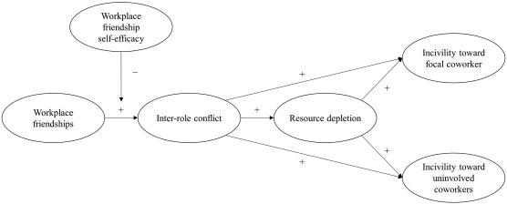

Fig. 1. Conceptual model of managing the risks and side effects of workplace friendships.

## 2. Hypotheses development

### 2.1. Workplace friendships and the indirect relation with incivility via inter-role conflict and resource depletion

We argue that workplace friendships can lead to incivility via inter-role conflict and subsequent resource depletion, due to the different and potentially conflicting demands placed on individuals in their roles as “employee” and “friend” at work. First, workplace friendships can lead to inter-role conflict because the different role expectations attached to “employee” and “friend” are sometimes mutually exclusive (Bridge & Baxter, 1992). For example, employees reported that workplace friendships resulted in “a sense of divided loyalty between the needs of a friend vs. the needs of the organization” (Bridge & Baxter, 1992, pp. 216–217). More specifically, individuals experience inter-role conflict because they need to make decisions about which role to prioritize (Fasbender & Drury, 2022; Kahn et al., 1964; Methot et al., 2016). To illustrate, if employees decide to invest their limited resources into the time-sensitive completion of a work report, they might not be able to respond appropriately to the immediate socioemotional needs of a workplace friend. In line with our argument, an exploratory study found that workplace friendships can lead to inter-role conflict between friendship- and task-related aspects of the work role (Hommelhoff, 2019). We thus expect that workplace friendships are positively associated with inter-role conflict.

Second, inter-role conflict can lead to resource depletion because employees tend to invest their resources into navigating the tensions between their formal role as “employee” and their informal role as “friend” (Methot et al., 2016). In doing so, employees need to regulate the allocation of attention and resources across incompatible role demands, which consumes regulatory resources (Beal et al., 2005) and leads to resources being lost in the attempt to juggle both roles (Bamberger et al., 2017; Grandey & Cropanzano, 1999). This investment of self-regulatory resources to reconcile competing role demands leads to feelings of depletion, represented by having difficulties to concentrate, or feeling drained and unfocused at work. Taken together, and supported by research that found that role stressors are linked to several forms of employee strain (e.g., exhaustion, fatigue; Barling & Frone, 2017; Barling & Macintyre, 1993; Rivkin et al., 2015), we expect that inter-role conflict is positively associated with resource depletion.

Third, resource depletion can lead employees to instigate incivility because complying with workplace norms requires the investment of self-regulatory resources, which are not available to employees when their resources are depleted. Deviant behavior “can be thought of as self-regulatory failures” (Rosen et al., 2016, p. 1621) because when employees experience resource depletion, they lack the resources necessary to suppress deviant behaviors and act in a way that is consistent with workplace norms (Christian & Ellis, 2011; Rosen et al., 2016). When employees' resources are depleted, they may struggle to suppress rude and discourteous behavior at work. For example, they may be less able to take the perspective of their coworkers or do not think too much about the consequences of their behavior, which can result in instigating incivility at work. In line with our argument, previous research has shown that resource depletion is linked to deviant behavior, such as impulsive, unethical, or [aggressive behavior](https://www-sciencedirect-com.ezproxy.spu.edu/topics/psychology/aggression) toward others (Christian & Ellis, 2011; DeWall et al., 2007; Jahanzeb & Fatima, 2018; Lin et al., 2016) as well as incivility (Rosen et al., 2016).

Importantly, research suggests that incivility can be directed at different targets (Zappalà et al., 2022). Thus, it seems worthwhile to disentangle whether depleted employees instigate incivility toward their workplace friends or toward other coworkers who are not workplace friends. From an attribution perspective, it seems likely that resource-depleted employees enact incivility toward their workplace friends because they identify interactions with their friends at work as the source of the problem that is to blame for their loss of resources. Employees might thus retaliate by instigating incivility toward workplace friends. In addition, friendship norms, which emphasize acceptance, favoritism, and affection (Bridge & Baxter, 1992), would suggest that workplace friends occupy a special position in the focal employees' social hierarchy and employees might thus instigate incivility toward other coworkers. Research showed that employees can redirect deviant behaviors toward innocent targets to restore perceptions of control if the source of the problem is (for whatever reason) difficult or impossible to reach (Martinko et al., 2013). Taken together, we expect that workplace friendships have indirect relations with incivility in general, incivility toward workplace friends, and incivility toward other coworkers via inter-role conflict and resource depletion.

**Hypothesis 1**

Workplace friendships have positive indirect relations with (a) incivility, (b) incivility toward workplace friends, and (c) incivility toward other coworkers via inter-role conflict and subsequent resource depletion.

### 2.2. The buffering role of workplace friendship self-efficacy

We argue that workplace friendship self-efficacy buffers the positive effect of workplace friendships on inter-role conflict, thereby mitigating the downstream consequences on incivility. General self-efficacy affects a large variety of employee outcomes (Gist & Mitchell, 1992), and has been shown to help employees persist in the face of adversity (Lent et al., 1987), deal more effectively with challenging situations (Hill et al., 1987), and generate more benefits from opportunities (Alessandri et al., 2015). More specifically, research on the moderating role of self-efficacy at work found that believing in one's abilities can help employees to effectively respond to challenges and buffer the negative effects of several work-related demands (Brown et al., 2001; Jex & Bliese, 1999). For example, Brown et al. (2001) showed that employees with higher (vs. lower) self-efficacy were better able to deal with the demands of information seeking and more likely to effectively interpret information to clarify role expectations. Accordingly, employees with higher self-efficacy are more effective in interpreting ambiguous information because they are less distracted and hence waste less cognitive resources with rumination about perceived inadequacies (see Bandura, 1997).

More specifically, employees who are self-efficacious regarding their workplace friendships are confident in their ability to manage their friendships at work (Bagci et al., 2019; Fitzpatrick & Bussey, 2014). We expect that the link between workplace friendships and inter-role conflict is less pronounced when workplace friendship self-efficacy is higher (vs. lower). This is because individuals develop beliefs about their capabilities and adapt to changing demands based on information provided by their social context and interactions with their social environment (Bandura, 1997; Gist & Mitchell, 1992). Employees with higher workplace friendship self-efficacy believe that they can effectively manage their workplace friendships based on their experiences and their ability to deal with interpersonal issues. Workplace friendship self-efficacy thus enables employees to navigate their role as workplace friend more effectively, which reduces the perceived conflict with their formal role as employee.

Research has yet to test the moderating role of workplace friendship self-efficacy for the detrimental effects of workplace friendships on inter-role conflict and its downstream consequences. However, the limited research on the moderating role of friendship self-efficacy found that it can buffer the negative effects of social victimization (i.e., socially aggressive behaviors targeted at seemingly powerless individuals; Fitzpatrick & Bussey, 2014). Accordingly, workplace friendship self-efficacy strengthens individuals' belief in being proactive agents who can shape and exercise control over their social environment. Taken together, we expect that workplace friendship self-efficacy buffers the positive link between workplace friendships and inter-role conflict.

**Hypothesis 2**

Workplace friendship self-efficacy moderates the positive relation between workplace friendships and inter-role conflict, such that the positive relation is weaker when workplace friendship self-efficacy is higher (vs. lower).

Integrating our arguments, we expect that workplace friendship self-efficacy buffers the detrimental downstream consequences of workplace friendships on instigated incivility. Specifically, the positive links between workplace friendships and incivility via inter-role conflict and subsequent resource depletion are weaker when workplace friendship self-efficacy is higher (vs. lower).

**Hypothesis 3**

The positive indirect relations between workplace friendships and (a) incivility, (b) incivility toward workplace friends, and (c) incivility toward other coworkers via inter-role conflict and subsequent resource depletion are weaker when workplace self-efficacy is higher (vs. lower).

We test our hypotheses using two studies. In Study 1, we focus on incivility as generic construct that does not differentiate between coworkers who are involved in the focal friendship and non-involved others. In Study 2, we specify the relationship with one particular coworker and the behavior toward that particular coworker vs. non-involved others to parcel out the target of incivility. Specifically, employees report about their relationship to, experiences with, and behavior toward one focus person in addition to other non-involved coworkers. By specifying a focus person, we are able to disentangle the target of incivility, that is whether employees instigate incivility toward the focal person or other coworkers.

## 3. Study 1

### 3.1. Method

#### 3.1.1. Sample and procedure

We collected three waves of data in collaboration with a certified data collection organization (i.e., Respondi) in 2019. About 5000 employees working in different industries and organizations in the United Kingdom (UK) were contacted via email if they were at least 18 years old and employed for a minimum of 20 h per week. We decided to collect a sample from employees working in different organizations to increase the generalizability of our findings and the variance in organizational contexts, which is relevant due to the contextual moderator in our model. Each participant was asked to fill out three online questionnaires with a time lag of two weeks in between. We time-separated our measures to offer a stronger causal inference (Wang et al., 2017) and to reduce common-method bias (Podsakoff et al., 2003). Two weeks were chosen as the time lag because previous research suggested the use of short time interval research designs to identify the strongest possible relations by limiting the probability of the occurrence of individual or organizational events that could override the investigated relations (Dormann & Griffin, 2015).

At Time 1, 661 participants responded to the survey (i.e., response rate of 13.2 %), of which 516 also participated at Time 2 (dropout rate = 21.9 %), and 451 at Time 3 (dropout rate = 12.6 %). We therefore had 451 participants in our final sample. Participants worked in diverse industries (i.e., 12.4 % public sector, 8.9 % professional services, 8.4 % consumer goods, 8.4 % [health care](https://www-sciencedirect-com.ezproxy.spu.edu/topics/psychology/healthcare), 8.4 % education and research, 7.8 % media, technology and telecommunications, 6.2 % industrial goods, 6.0 % finance and insurance, 4.2 % non-profit sector, 2.9 % energy and infrastructure, and 26.4 % other industries). On average, participants worked 38.33 h per week (*SD* = 6.63). The average age of participants was 49.54 years (*SD* = 11.24). Of all participants, 40.1 % were women.

To investigate potential attrition effects, we followed the stepwise procedure recommended by Goodman and Blum (1996). Specifically, we tested if the final sample (“stayers”) differed from the group of “leavers” including participants who dropped out. We entered all variables at Time 1 in a multiple logistic [regression analysis](https://www-sciencedirect-com.ezproxy.spu.edu/topics/psychology/regression-analysis) predicting the probability of being included in the final sample to assess the presence of non-random sampling. The results of the multiple logistic regression analysis revealed no effects of the control variables nor the study variables except for age and gender, indicating that older participants were more likely to remain and female participants were less likely to remain in the sample. Therefore, we also investigated the mean differences of the “stayers” and “leavers” in age and gender with *t*-tests for independent samples and found significant differences for age (*M*<sub>stayers</sub> = 49.54 (*SD* = 11.27), *M*<sub>leavers</sub> = 47.03 (*SD* = 11.79), (*t*(659) = −2.625, *p* = .009) and gender (*M*<sub>stayers</sub> = 0.40 (*SD* = 0.49), *M*<sub>leavers</sub> = 0.52 (*SD* = 0.50), (*t*(659) = 2.853, *p* = .004). Moreover, we estimated differences in variance between the “stayers” and the whole sample as suggested by Goodman and Blum (1996). However, no significance differences in variance occurred for age (χ<sup>2</sup> (450) = 432.095, *p* = .719) and gender (χ<sup>2</sup> (450) = 439.069, *p* = .635). Finally, we conducted a sensitivity analysis to investigate whether the results differ between “stayers” and the whole sample. Results showed that the estimated relationships remained stable, which indicates that non-random sampling is not a major concern in the data at hand.

#### 3.1.2. Measures

Unless indicated elsewise, we asked participants to respond on a five-point [Likert scale](https://www-sciencedirect-com.ezproxy.spu.edu/topics/psychology/likert-scale) ranging between 1 (*Strongly disagree*) and 5 (*Strongly agree*).

##### 3.1.2.1. Workplace friendships

At Time 1, we measured the prevalence of workplace friendships with the six-item scale from Nielsen et al. (2000) that captures the extent to which employees have friendships at work. An example item was “I have formed strong friendships at work” (Cronbach's α = 0.90).

##### 3.1.2.2. Workplace friendship self-efficacy

At Time 1, we measured workplace friendship self-efficacy with four items derived from Judge et al.'s (1998) general self-efficacy scale. We adapted the scale to the work domain by adding the word “at work” to each item, and by specifically referring to managing workplace friendships. An example item was “At work, I am able to manage workplace friendships” (Cronbach's α = 0.88).

##### 3.1.2.3. Inter-role conflict

At Time 2, we measured inter-role conflict with five items adapted from the work-family conflict scale by Netemeyer et al. (1996). We adapted the items to the workplace friendship context, by changing references from work-family to workplace friendship based on the conceptual work by Pillemer and Rothbard (2018; see also research by Ingram & Zou, 2008; Hommelhoff, 2019). We asked participants to report whether they experienced conflict between their role as employee and workplace friend in the last two weeks. The items were introduced with “In the last two weeks…”; an example item was “Socializing with my coworkers interfered with my responsibilities at work” (Cronbach's α = 0.94).

##### 3.1.2.4. Resource depletion

At Time 2, we measured depletion with the five-item scale from Lanaj et al. (2014). Participants indicated how often they experienced depletion in the last two weeks on a five-point scale ranging from 1 (*Never*) to 5 (*Always*)*.* The items were introduced with “In the last two weeks, how often did you experience the following?” An example item was “I felt drained” (Cronbach's α = 0.93).

##### 3.1.2.5. Instigating incivility

At Time 3, we measured instigating incivility with the seven-item scale from Bennett and Robinson (2000) that captures the extent to which employees have acted impolitely or rudely toward their coworkers on a five-point scale ranging from 1 (*Never*) to 5 (*Always*)*.* The items were introduced with “In the last two weeks, how often did you engage in the following?” An example item was “Acted rudely toward my coworkers” (Cronbach's α = 0.92).

#### 3.1.3. Analytic strategy

To test our hypotheses, we ran structural equation modeling in *Mplus* 8.4 (Muthén & Muthén, 2019). In doing so, the control variables (i.e., age, gender, and contact frequency) were regressed on the mediators (i.e., inter-role conflict, resource depletion) and the outcome variable (i.e., incivility).

To test the serial indirect effects of workplace friendships on incivility via inter-role conflict and subsequent resource depletion, we controlled for the direct effects of workplace friendships on resource depletion and incivility to limit the inflation of the estimated indirect effect (Preacher & Hayes, 2008). We ran parameter-based bootstrapping with the Monte Carlo method for deriving the confidence intervals of the indirect effects (Preacher & Selig, 2012) in *R* (R Core Team, 2017).

To test the moderating role of workplace friendship self-efficacy, we regressed the latent interaction between workplace friendship and workplace friendship self-efficacy on inter-role conflict and tested the simple slopes at higher (+1SD) and lower (−1SD) values of the moderator (Aiken and West, 1991). Finally, we ran parameter-based bootstrapping with the Monte Carlo method to estimate the confidence interval of the resulting compound coefficient and the conditional indirect effects.

### 3.2. Results

#### 3.2.1. Preliminary analysis

In Table 1, we show the means, standard deviations, and correlations of Study 1 variables. In Table 2, we display the fit indices for the confirmatory factor analyses. The hypothesized five-factor model showed an excellent fit to the data, and fit better than the alternative four-, and one-factor models. In addition, the standardized factor loadings of the items on their corresponding latent factors ranged from 0.60 to 0.94 and were all significant. These results support the construct validity of the measures we used in Study 1.

Table 1. Study 1. Means, standard deviations, and correlations of study variables.

Variable

M

SD

1.

2.

3.

4.

5.

6.

7.

8.

- 1.

  Age

49.54

11.24

–

- 2.

  Gender (1 = *female*)

0.40

0.49

−0.06

–

- 3.

  Contact frequency

4.43

0.74

−0.08

0.04

–

- 4.

  Workplace friendships

3.37

0.89

−0.03

0.03

**0.28**

(0.90)

- 5.

  Workplace friendship self-efficacy

4.05

0.65

**0.15**

–0.02

**0.21**

**0.48**

(0.88)

- 6.

  Inter-role conflict

2.02

0.89

**−0.20**

–0.01

0.05

0.07

**–0.16**

(0.94)

- 7.

  Resource depletion

2.52

0.96

**−0.24**

**0.16**

0.01

–0.03

**−0.14**

**0.41**

(0.93)

- 8.

  Incivility

1.33

0.62

**−0.14**

**–0.13**

0.07

0.09

−0.03

**0.28**

**0.30**

(0.92)

*Note. N* = 451. Reliabilities (Cronbach's alpha) are shown in parentheses on the diagonal. Significant coefficients are highlighted in bold.

Table 2. Study 1. Confirmatory factor analysis fit indices for measurement model.

| Model | χ<sup>2</sup> | df | Δχ<sup>2</sup> (Δ*df*) | *p*-value Δχ<sup>2</sup> (Δ*df*) | CFI | RMSEA | SRMR |
| --- | --- | --- | --- | --- | --- | --- | --- |
| Five-factor model | 710.560 | 314 | – | – | 0.960 | 0.053 | 0.044 |
| Four-factor model<sup>a</sup> | 1440.828 | 318 | 730.268 (4) | <0.001 | 0.86 | 0.088 | 0.075 |
| Four-factor model<sup>b</sup> | 2394.722 | 318 | 1684.162 (4) | <0.001 | 0.790 | 0.120 | 0.105 |
| One-factor model | 7187.791 | 324 | 6477.231 (10) | <0.001 | 0.306 | 0.217 | 0.232 |

*Note. N* = 451. Difference of chi-square values (Δχ<sup>2</sup>) was estimated to compare to the seven-factor model. CFI = Confirmatory Fit Index, RMSEA = Root Mean Square Error of Approximation, SRMR = Standardized Root Mean Square Residual.

**a**

Workplace friendships and workplace friendship self-efficacy on one factor.

**b**

Inter-role conflict and resource depletion on one factor.

#### 3.2.2. Hypotheses testing

In Table 3, we show the coefficient estimates for the hypothesized model. In Table 4, we display the estimates for hypothesized indirect effects. Hypothesis 1a addressed the serial indirect effect of workplace friendships on incivility via inter-role conflict and subsequent resource depletion. Workplace friendships were positively related to inter-role conflict (γ = 0.25, *SE* = 0.08, *p* = .001), inter-role conflict was positively related to resource depletion (γ = 0.38, *SE* = 0.05, *p* < .001), and resource depletion was positively related to incivility (γ = 0.19, *SE* = 0.05, *p* < .001). The serial indirect effect was significant (*indirect effect* = 0.018, 95 % CI [0.005, 0.037]), supporting Hypothesis 1a.

Table 3. Study 1. Results of structural equation modeling including control variables.

| Empty Cell | Inter-role conflict Coeff | Inter-role conflict SE | Inter-role conflict p-value |
| --- | --- | --- | --- |
| Age | **−0.014** | 0.004 | 0.001 |
| Gender (1 = *female*) | −0.040 | 0.089 | 0.653 |
| Contact frequency | 0.072 | 0.058 | 0.218 |
| Workplace friendships (A) | **0.251** | 0.078 | 0.001 |
| Workplace friendship self-efficacy (B) | **−0.542** | 0.104 | <0.001 |
| Interaction (A × B) | **−0.380** | 0.081 | <0.001 |
| R<sup>2</sup> | **0.137** | 0.036 | <0.001 |

| Empty Cell | Resource depletion Coeff | Resource depletion SE | Resource depletion p-value |
| --- | --- | --- | --- |
| Age | **−0.012** | 0.004 | 0.001 |
| Gender (1 = *female*) | **0.277** | 0.080 | 0.001 |
| Contact frequency | −0.003 | 0.060 | 0.985 |
| Workplace friendships | −0.069 | 0.075 | 0.354 |
| Workplace friendship self-efficacy | −0.042 | 0.110 | 0.703 |
| Inter-role conflict | **0.380** | 0.052 | <0.001 |
| R<sup>2</sup> | **0.236** | 0.038 | <0.001 |

| Empty Cell | Incivility Coeff | Incivility SE | Incivility p-value |
| --- | --- | --- | --- |
| Age | −0.002 | 0.003 | 0.442 |
| Gender (1 = *female*) | **−0.194** | 0.058 | 0.001 |
| Contact frequency | 0.011 | 0.034 | 0.738 |
| Workplace friendships | 0.089 | 0.052 | 0.088 |
| Workplace friendship self-efficacy | −0.050 | 0.080 | 0.088 |
| Inter-role conflict | **0.082** | 0.037 | 0.025 |
| Resource depletion | **0.186** | 0.052 | <0.001 |
| *R*<sup>2</sup> | **0.157** | 0.031 | <0.001 |

*Note. N* = 451. Coeff = unstandardized coefficient, *SE* = standard error of unstandardized coefficient. Significant coefficients are highlighted in bold.

Table 4. Study 1. Indirect effects and conditional indirect effects of workplace friendships on incivility.

| Empty Cell | Indirect Effects Coeff | Indirect Effects CI LL | Indirect Effects CI UL |
| --- | --- | --- | --- |
| Workplace friendships → inter-role conflict → resource depletion → incivility | **0.018** | 0.005 | 0.037 |
| At higher (+1*SD*) workplace friendship self-efficacy | 0.003 | −0.009 | 0.018 |
| At lower (−1*SD*) workplace friendship self-efficacy | **0.032** | 0.012 | 0.060 |
| Difference between higher and lower levels of workplace friendship self-efficacy | **−0.029** | −0.054 | −0.011 |
| Index of moderated mediation (compound effect) | **−0.027** | −0.051 | −0.010 |

*Note. N* = 451. Coeff = unstandardized coefficient, CI LL = lower level of bias-corrected 95 % confidence interval, CI UL = upper level of bias-corrected 95 % confidence interval. Significant coefficients are highlighted in bold.

Hypothesis 2 addressed the moderating role of workplace friendship self-efficacy on the relation of workplace friendships with inter-role conflict. We found that workplace friendship self-efficacy buffered the positive relation of workplace friendships with inter-role conflict (γ = −0.38, *SE* = 0.08, *p* < .001). Simple slope difference tests showed that the effect of workplace friendships was non-significant at higher levels of workplace friendship self-efficacy (*simple slope* = 0.05, *SE* = 0.09, *p* = .604) and positive at lower levels of workplace friendship self-efficacy (*simple slope* = 0.46, *SE* = 0.09, *p* < .001, *slope difference* = −0.41, *SE* = 0.09, *p* < .001). We plotted the interaction in Fig. 2. These findings supported Hypothesis 2.

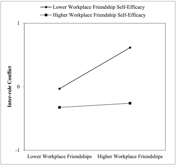

Fig. 2. Workplace friendship self-efficacy moderates the relation between workplace friendships and inter-role conflict.

Hypothesis 3a addressed the moderating role of workplace friendship self-efficacy on the indirect relations of workplace friendships with incivility via inter-role conflict and subsequent resource depletion. In line with Hypothesis 3a, we found that the indirect moderation effect was negative (*compound effect* = −0.03, 95 % CI [−0.05, −0.01]). The indirect effect of workplace friendships on incivility via inter-role conflict and resource depletion was non-significant at higher levels of workplace friendship self-efficacy (*conditional indirect effect = 0*.003, 95 % CI [−0.01, 0.02]) and positive at lower levels of organizational friendship support (*conditional indirect effect = 0*.03, 95 % CI [0.01, 0.06]). The difference between the two serial indirect effects was significant (*difference* = −0.03, 95 % CI [−0.05, −0.01]). Together, these findings support Hypothesis 3a.

#### 3.2.3. Supplementary analysis

We conduced statistical analyses to assess whether common-method variance was a concern in our data. Following the recommendation of Podsakoff et al. (2003), we used a “marker” variable (i.e., organizational friendship support; 6-item scale, Cronbach's α = 0.85; adapted from Nielsen et al., 2000) in our model and regressed it on all study variables (including predictor, mediator, and outcome variables) to partial out the marker as a surrogate for method variance. The results indicate that our findings are robust regardless of whether we included or excluded the marker variable in the model, which greatly reduces the concern for common-method variance.

Further, we tested whether the investigated relations are robust by estimating our hypothesized model with and without age, gender, and contact frequency as our control variables (Bernerth & Aguinis, 2016). We found that the pattern of the estimated direct and indirect effects remained the same regardless of whether we ran the model with or without control variables, which further strengthens the robustness of the findings.

### 3.3. Discussion of Study 1 findings

In Study 1, we found that workplace friendships were related to instigated incivility at work via inter-role conflict and resource depletion. In addition, our findings showed that workplace friendship self-efficacy buffered the detrimental effects of workplace friendships on inter-role conflict and mitigated the downstream consequences on incivility. While the results of Study 1 are interesting, there are shortcomings. We captured workplace friendships as a general phenomenon and did not delineate the target of incivility. We thus conducted a second study to provide more specificity by asking participants to report about their relationship and experiences with one particular (randomly chosen) coworker and provide data on incivility toward that focal person and toward other coworkers.

## 4. Study 2

### 4.1. Method

#### 4.1.1. Sample and procedure

As in Study 1, we collected the data in collaboration with a certified data collection organization (i.e., Respondi) in 2022. This time, we asked employees about their relationship to one particular coworker. To reduce the possibility of selection effects (see recommendations of Fasbender & Drury, 2022), we asked employees to provide names of three coworkers with whom they regularly interact at work. We then randomly selected one of these three coworkers to be the focal person. We programmed the survey in a way that the focal person's name was included in the respected items. Please find the full instruction in the appendix.

Again, employees working in different industries and organizations in the United Kingdom (UK) were contacted via email if they were at least 18 years old and employed for a minimum of 20 h per week. Each participant was asked to fill out three online questionnaires with a time lag of two weeks in between as in Study 1. At Time 1, 757 participants responded to the survey. We excluded 41 participants because they did not provide names of three coworkers or they provided names that did not make sense (e.g., provided only initials). Of all participants, we therefore invited 716 to take part in the follow-up surveys, of which 573 also participated at Time 2 (dropout rate = 20.0 %), and 499 at Time 3 (dropout rate = 12.9 %). We therefore had 499 participants in our final sample. Participants worked in diverse industries, most represented industries were [health care](https://www-sciencedirect-com.ezproxy.spu.edu/topics/psychology/healthcare) and social work (13.4 %), the public sector (12.0 %), and education (11.8 %). On average, participants worked 37.85 h per week (*SD* = 8.82). The average age of participants was 45.73 years (*SD* = 10.93). Of all participants, 43.1 % were women.

As in Study 1, we investigated potential attrition effects by entering all variables at Time 1 in a multiple logistic [regression analysis](https://www-sciencedirect-com.ezproxy.spu.edu/topics/psychology/regression-analysis) predicting the probability of being included in the final sample (Goodman & Blum, 1996). The results of the multiple logistic regression analysis showed no significant differences in any of the included variables, indicating that non-random sampling was not present in the data at hand.

#### 4.1.2. Measures

Unless indicated elsewise, we asked participants to respond on a five-point [Likert scale](https://www-sciencedirect-com.ezproxy.spu.edu/topics/psychology/likert-scale) ranging between 1 (*Strongly disagree*) and 5 (*Strongly agree*).

##### 4.1.2.1. Friendship closeness

At Time 1, we measured friendship closeness using the 1-item measure by Bridge and Baxter (1992). We used friendship closeness to account for the specific relationship to one particular person. The item was introduced with “Reflecting about the relationship with [placeholder, e.g., Lisa]…”, followed by the item “How would you describe your relationship with [placeholder, e.g., Lisa]?”. The scale ranged from 1 (*Just colleagues*) to 5 (*Best friends*).

##### 4.1.2.2. Workplace friendship self-efficacy

At Time 1, we measured workplace friendship self-efficacy with the same scale as in Study 1 (Cronbach's α = 0.89).

##### 4.1.2.3. Inter-role conflict

At Time 1, we measured inter-role conflict with the scale used in Study 1.<sup>1</sup> We adapted the scale by adding the focal person to the item. An example item was “Socializing with [placeholder, e.g., Lisa] interfered with my responsibilities at work” (Cronbach's α = 0.94).

##### 4.1.2.4. Resource depletion

At Time 2, we measured resource depletion with the same scale as in Study 1 (Cronbach's α = 0.94).

##### 4.1.2.5. Instigating incivility

At Time 3, we measured instigating incivility with the 4-item scale adapted from Rosen et al. (2016). We adapted the scale to capture incivility toward the focal person vs. uninvolved others. The items were introduced with “In the last two weeks…” An example item for incivility toward focal person was “I put [placeholder, e.g., Lisa] down or acted condescending toward him/her” (Cronbach's α = 0.91), and an example item for incivility toward uninvolved others was “I put my coworkers (other than [placeholder, e.g., Lisa]) down or acted condescending toward them?” (Cronbach's α = 0.92).

##### 4.1.2.6. Control variables

We controlled for employees' age, gender, and contact frequency with coworkers as in Study 1. In addition, we controlled for trait negative affect to rule out the possibility that the hypothesized negative effects of friendship closeness were caused by the mere negative affectivity. We measured negative affect using the short PANAS (Mackinnon et al., 1999; Watson et al., 1988) with five items (e.g., “upset”; α = 0.93).

### 4.2. Results

We followed the same analytical strategy as in Study 1.

#### 4.2.1. Preliminary analysis

In Table 5, we show the means, standard deviations, and correlations of Study 2 variables. In Table 6, we display the fit indices for the confirmatory factor analyses. The hypothesized five-factor model showed again an excellent fit to the data and the fit was better than for the alternative models. The standardized factor loadings of the items on their corresponding latent factors ranged from 0.75 to 0.92 and were all significant. These results support the construct validity of the measures we used in Study 2.

Table 5. Study 2. Means, standard deviations, and correlations of study variables.

Variable

M

SD

1.

2.

3.

4.

5.

6.

7.

8.

9.

10.

- 1.

  1. Age

45.73

10.93

–

- 2.

  2. Gender (1 = *female*)

0.43

0.50

**−0.28**

–

- 3.

  3. Contact frequency

3.83

1.14

0.03

−0.04

–

- 4.

  4. Negative affect

1.98

0.93

**−0.18**

**0.13**

**−0.11**

(0.93)

- 5.

  5. Friendship closeness

2.88

0.90

−0.01

**–0.09**

**0.41**

−0.08

–

- 6.

  6. Workplace friendship self-efficacy

4.23

0.60

0.05

–0.03

**0.19**

**−0.34**

**0.30**

(0.89)

- 7.

  7. Inter-role conflict

1.71

0.89

**−0.15**

–0.06

**0.09**

**0.19**

**0.11**

**–0.21**

(0.94)

- 8.

  8. Resource depletion

2.58

1.02

**−0.24**

**0.18**

–0.02

**0.57**

–0.07

**−0.20**

**0.25**

(0.94)

- 9.

  9. Incivility toward focal coworker

1.55

0.76

**−0.13**

–0.06

−0.02

**0.27**

–0.04

**−0.32**

**0.46**

**0.28**

(0.91)

- 10.

  10. Incivility toward other coworkers

1.60

0.82

**−0.16**

–0.08

0.05

**0.24**

0.02

**−0.23**

**0.40**

**0.30**

**0.62**

(0.92)

*Note. N* = 499. Reliabilities (Cronbach's alpha) are shown in parentheses on the diagonal. Significant coefficients are highlighted in bold.

Table 6. Study 2. Confirmatory factor analysis fit indices for measurement model.

| Model | χ<sup>2</sup> | df | Δχ<sup>2</sup> (Δ*df*) | *p*-value Δχ<sup>2</sup> (Δ*df*) | CFI | RMSEA | SRMR |
| --- | --- | --- | --- | --- | --- | --- | --- |
| Five-factor model | 573.269 | 199 | – | – | 0.960 | 0.061 | 0.031 |
| Four-factor model<sup>a</sup> | 1346.951 | 203 | 773.682 (4) | <0.001 | 0.878 | 0.106 | 0.055 |
| Four-factor model<sup>b</sup> | 2823.095 | 203 | 2249.826 (4) | <0.001 | 0.721 | 0.161 | 0.142 |
| One-factor model | 6004.921 | 209 | 5431.652 (10) | <0.001 | 0.382 | 0.236 | 0.177 |

*Note. N* = 499. Difference of chi-square values (Δχ<sup>2</sup>) was estimated to compare to the seven-factor model. CFI = Confirmatory Fit Index, RMSEA = Root Mean Square Error of Approximation, SRMR = Standardized Root Mean Square Residual.

**a**

Incivility toward focal coworker and incivility toward other coworkers on one factor.

**b**

Inter-role conflict and resource depletion on one factor.

#### 4.2.2. Hypotheses testing

In Table 7, we show the coefficient estimates for the hypothesized model. In Table 8, we display the estimates for indirect effects. Hypotheses 1b and 1c addressed the serial indirect effect of friendship closeness on incivility toward the focal coworker vs. other coworkers via role conflict and resource depletion. Friendship closeness positively related to inter-role conflict (γ = 0.13, *SE* = 0.05, *p* = .014). We also found a positive effect of inter-role conflict (γ = 0.17, *SE* = 0.05, *p* = .001) on resource depletion.

Table 7. Study 2. Results of structural equation modeling including control variables.

| Empty Cell | Inter-role conflict Coeff | Inter-role conflict SE | Inter-role conflict p-value |
| --- | --- | --- | --- |
| Age | **−0.011** | 0.004 | 0.003 |
| Gender (1 = *female*) | **−0.182** | 0.077 | 0.017 |
| Contact frequency | **0.064** | 0.030 | 0.034 |
| Negative affect | **0.121** | 0.058 | 0.040 |
| Friendship closeness (A) | **0.134** | 0.054 | 0.014 |
| Workplace friendship self-efficacy (B) | **−0.401** | 0.098 | <0.001 |
| Interaction (A × B) | −0.003 | 0.120 | 0.978 |
| R<sup>2</sup> | **0.149** | 0.038 | <0.001 |

| Empty Cell | Resource depletion Coeff | Resource depletion SE | Resource depletion p-value |
| --- | --- | --- | --- |
| Age | **−0.010** | 0.003 | 0.004 |
| Gender (1 = *female*) | **0.164** | 0.072 | 0.023 |
| Contact frequency | 0.036 | 0.033 | 0.268 |
| Negative affect | **0.544** | 0.051 | <0.001 |
| Friendship closeness | −0.071 | 0.042 | 0.090 |
| Workplace friendship self-efficacy | 0.100 | 0.084 | 0.233 |
| Inter-role conflict | **0.166** | 0.052 | 0.001 |
| R<sup>2</sup> | **0.384** | 0.040 | <0.001 |

| Empty Cell | Incivility toward focal coworker Coeff | Incivility toward focal coworker SE | Incivility toward focal coworker p-value | Incivility toward other coworkers Coeff | Incivility toward other coworkers SE | Incivility toward other coworkers p-value |
| --- | --- | --- | --- | --- | --- | --- |
| Age | −0.005 | 0.003 | 0.088 | **−0.007** | 0.003 | 0.023 |
| Gender (1 = *female*) | −0.130 | 0.063 | 0.038 | **−0.210** | 0.074 | 0.004 |
| Contact frequency | −0.002 | 0.032 | 0.961 | 0.028 | 0.026 | 0.279 |
| Negative affect | 0.073 | 0.053 | 0.168 | 0.034 | 0.057 | 0.165 |
| Friendship closeness | −0.017 | 0.036 | 0.640 | 0.018 | 0.038 | 0.640 |
| Workplace friendship self-efficacy | **−0.306** | 0.078 | <0.000 | **−0.230** | 0.099 | 0.020 |
| Inter-role conflict | **0.330** | 0.057 | <0.000 | **0.277** | 0.061 | <0.000 |
| Resource depletion | 0.042 | 0.048 | 0.382 | **0.154** | 0.059 | 0.009 |
| *R*<sup>2</sup> | **0.328** | 0.040 | <0.001 | 0.272 | 0.052 | <0.001 |

*Note. N* = 499. Coeff = unstandardized coefficient, *SE* = standard error of unstandardized coefficient. Significant coefficients are highlighted in bold.

Table 8. Study 2. Indirect effects of friendship closeness on incivility toward focal coworker and other coworkers.

| Empty Cell | Indirect Effects Coeff | Indirect Effects CI LL | Indirect Effects CI UL |
| --- | --- | --- | --- |
| Friendship closeness → inter-role conflict → incivility toward focal coworker | **0.044** | 0.022 | 0.071 |
| Friendship closeness → inter-role conflict → resource depletion → incivility toward focal coworker | 0.001 | −0.001 | 0.003 |
| Friendship closeness → inter-role conflict → incivility toward other coworkers | 0.037 | 0.017 | 0.062 |
| Friendship closeness → inter-role conflict → resource depletion → incivility toward other coworkers | **0.003** | 0.001 | 0.006 |

*Note. N* = 499. Coeff = unstandardized coefficient, CI LL = lower level of bias-corrected 95 % confidence interval, CI UL = upper level of bias-corrected 95 % confidence interval. Significant coefficients are highlighted in bold.

With regard to incivility toward the focal coworker, we found that the effect of resource depletion was not significant (γ = 0.04, *SE* = 0.05, *p* = .382). The indirect effect of friendship closeness on incivility toward the focal person via inter-role conflict and resource depletion was also not significant (*indirect effect* = 0.001, 95 % CI [−0.001, 0.003]). Hypothesis 1b was therefore not supported.

With regard to incivility toward the other coworkers, we found a positive effect of resource depletion (γ = 0.15, *SE* = 0.06, *p* = .009). Furthermore, we found a significant indirect effect of friendship closeness on incivility toward other coworkers via inter-role conflict and resource depletion (*indirect effect* = 0.003, 95 % CI [0.001, 0.006]), supporting Hypothesis 1c.

Hypotheses 2 and 3 addressed the moderating role of workplace friendship self-efficacy on the relation of friendship closeness with inter-role conflict, and its indirect effects on incivility. The moderation effect of workplace friendship self-efficacy was however not significant (γ = −0.003, *SE* = 0.12, *p* = .978). Hypotheses 2 and 3 could therefore not be supported in Study 2.

#### 4.2.3. Supplementary analysis

As in Study 1, we conduced supplementary analyses to ensure the robustness of our findings. Again, assessed whether common-method variance was a concern using a marker variable (i.e., organizational friendship support, measured as in Study 1, Cronbach's α = 0.87) in our model and regressed it on all study variables (including predictor, mediator, and outcome variables) to partial out method variance. The analysis showed that our findings are comparable regardless of whether we included or excluded the marker variable in the model, which lowers the concern for common-method variance.

Moreover, we tested whether the investigated relations are robust by estimating our hypothesized model with and without age, gender, contact frequency, and negative affect as our control variables. While most of the estimated direct and indirect effects remained the same, we found that the indirect effect of friendship closeness on incivility toward the focal coworker was significant in the hypothesized direction if we ran the model without control variables (which provides some support for Hypothesis 1b).

### 4.3. Discussion of Study 2 findings

In Study 2, we partly replicated and extended the findings from Study 1 by showing that workplace friendships were indirectly related to incivility via inter-role conflict and subsequent resource depletion. Moreover, we were able to disentangle the target of incivility. We found that workplace friendships were indirectly linked to incivility toward other coworkers, but not to incivility toward workplace friends. However, we were unable to replicate the moderating effect of workplace friendship self-efficacy.

## 5. General discussion

With this research, we aimed at understanding the risks and side effects of workplace friendships for coworkers. Using the dialectical perspective of workplace friendships in combination with a self-regulatory perspective, we examined through which mechanisms workplace friendships can lead to low-intensity deviant behavior directed toward others at work and how employees can mitigate these risks and side effects. Across two studies, we found that workplace friendships were not correlated to instigated incivility but were indirectly linked to instigated incivility through inter-role conflict and subsequent resource depletion. Specifically, we found that workplace friendships led to instigated incivility toward coworkers, especially other coworkers rather than workplace friends, because employees experienced inter-role conflict and subsequent resource depletion. Further, we found evidence in one of the studies that employees' workplace friendship self-efficacy buffered these risks and side effects of workplace friendships.

### 5.1. Theoretical and practical implications

The findings of our study have implications for theorizing on workplace friendships, role conflicts, and workplace incivility. First, we extend the nomological network of the outcomes of workplace friendships by depicting its possible effects on low-intensity deviant behavior toward coworkers. This broadens current theorizing on the possible downsides of workplace friendships, which have been situated at the level of the focal individual, the group, and the organization (Pillemer & Rothbard, 2018). With our research, we add coworkers at the interpersonal level to the list of targets that might experience negative consequences. This is relevant because empirical studies so far focused on the potentially detrimental effects of workplace friendships for the focal employee. Accordingly, the seemingly incompatible instrumental and socioemotional demands of the roles as “employee” and “friend” can lead to reduced task performance (Methot et al., 2016). Hommelhoff (2019) started to extend this focus on the focal employee with a critical incident study by showing that workplace friendships can foster interpersonal conflicts between workplace friends. We complement this research by showing that workplace friendships can affect coworkers negatively in terms of incivility instigated toward them. More importantly, we provide nuance by demonstrating that uninvolved coworkers rather than workplace friends of the focal employees are likely to be the targets of incivility. This contributes to a more comprehensive portrait of the risks and side effects of workplace friendships.

Second, we specify one process through which workplace friendships are linked to incivility by showing that inter-role conflict and subsequent resource depletion explain how positive workplace relationships can facilitate negative work behavior. Our findings contribute to our understanding of how negative effects of workplace friendships manifest. Prior research argued that negative effects of workplace friendships for focal employees can be explained by perceived threats to one's self-concept (Ingram & Zou, 2008), distraction from instrumental goals (Pillemer & Rothbard, 2018), and exhaustion (Methot et al., 2016). Methot et al. (2016) called for researchers to add precision to the analysis of mediating mechanisms and specify the “difficulty” inherent in reconciling the demands of “employee” and “friend” roles at work. Utilizing the dialectical perspective on workplace friendships (Bridge & Baxter, 1992) enabled us to conceptualize the specific nature of the inter-role conflict triggered by workplace friendships. Further, integrating the dialectical perspective on workplace friendships (Bridge & Baxter, 1992) with a self-regulatory perspective (Beal et al., 2005) enabled us to specify the sequential nature of the mediating process. We thus provide nuance to research on workplace friendships aiming to understand how interpersonal work outcomes are affected.

In addition, our findings contribute to research on role conflicts more broadly. Research on role conflicts has advanced our understanding of inter-role and intra-role conflicts. Organizational research on inter-role conflicts has examined incompatible role demands between two different life roles, such as “employee” and “parent”, which are situated in two different life domains, such as work and non-work. Accordingly, important insights have been generated on the nature, causes, and consequences of work-nonwork conflict (Allen et al., 2012, Allen et al., 2015; Reichl et al., 2014). Organizational research on intra-role conflicts has examined tensions between different demands or foci of the “employee” role. For example, researchers examined how employees navigate simultaneous and potentially conflicting demands of multi-team membership (e.g., Berger & Bruch, 2021) and the role-related tensions of trainee positions in terms of conflict between filling a position and learning (e.g., junior doctors who are both doctor and trainee; Schaufeli et al., 2009). We add to this discussion of work-related conflicts by examining inter-role conflict in the context of workplace friendships (i.e., conflict between “employee” and “friend” role). In doing so, we integrate the work and nonwork domains by examining a typically private or nonwork-related role of being a “friend” (Bridge & Baxter, 1992) in the work domain.

Third, we contribute to research on workplace incivility, by highlighting workplace friendships as an unanticipated precursor of instigated incivility. Despite the tremendous costs and high prevalence of workplace incivility, not much is known about its antecedents (Schilpzand et al., 2016). Past research has identified instigator attitudes (e.g., job satisfaction, Blau & Andersson, 2005), instigator characteristics (e.g., trait anger, Meier & Semmer, 2013 or machiavellianism, Lata & Chaudhary, 2020), and situational antecedents (e.g., job demands, van Jaarsveld et al., 2010) of incivility. We contribute to this research stream on antecedents of incivility by adding a relational perspective. A better understanding of relational antecedents, such as workplace friendships, matters because even when workplace friendships come with benefits for employees, if they potentially harm others through higher levels of incivility toward involved or non-involved coworkers, it is relevant to know to “develop policies and interventions to diminish the prevalence of workplace incivility” (Schilpzand et al., 2016, p. 82).

In this regard, we further advance the literature by introducing workplace friendship self-efficacy as a moderator of the risks and side effects of workplace friendships. Systematically exploring the boundary conditions is relevant because it helps to further refine our understanding of workplace friendships and identify ways of reducing its unwanted consequences on incivility. Previous research has focused on [job characteristics](https://www-sciencedirect-com.ezproxy.spu.edu/topics/psychology/job-characteristics) (e.g., task interdependence; Zhang et al., 2021) and friendship characteristics (e.g., friendship maturity; Pillemer & Rothbard, 2018), thereby overlooking individual characteristics. We contribute to this literature by investigating workplace friendship self-efficacy as an individual-level moderator that buffers the negative consequences of workplace friendships. By demonstrating that workplace friendship self-efficacy helps employees to navigate their role as workplace friend more effectively in Study 1, we add an agentic lens to the research on boundary conditions of detrimental outcomes of workplace friendships. However, we were unable to replicate this moderation effect in Study 2, potentially due to range restriction in the moderator variable (i.e., the mean was 4.23, and the standard deviation was 0.60 on a scale ranging from 1 to 5) or due to the dyadic nature of workplace friendships that might require both employees involved in the friendship to be highly self-efficacious (three-way-interaction).

Finally, our findings also offer some practical implications that can help employees and organizations to effectively manage workplace friendships. As a starting point, employees need to be aware that, while workplace friendships have several benefits and can enrich our work life in important ways, they are not without risks and side effects. Employees need to acknowledge the downsides of workplace friendships to be able to manage their social relationships at work more effectively. To do so, it might be important to set expectations about professional interactions with workplace friends. For example, establishing that challenging each other in meetings is part of one's professional role can alleviate concerns about hurting the feelings of a workplace friend. In addition, setting expectations around the boundaries of one's availability to workplace friends can be important to protect time during the day to get work done. Scheduling dedicated times, such as lunch or coffee breaks, might be more effective than having to navigate frequent interruptions by workplace friends throughout the workday.

### 5.2. Limitations and directions for future research

Despite its theoretical and practical contributions, our study has several limitations that need to be considered when interpreting the results. One limitation is its correlational design, which prevents us from drawing conclusions about causality and examining developments over time. We used time-lagged data across three waves to test our hypotheses, which allows us to be more confident in testing predicted relations as compared to existing research on workplace friendships that is often based on either cross-sectional (e.g., Helmy et al., 2020; Hsu et al., 2019; Methot et al., 2016; Sias et al., 2020) or qualitative (e.g., Hommelhoff, 2019; Sias & Cahill, 1998) data (cf. Wang et al., 2017). To clarify causality, future research should use (quasi-) experimental designs in which the salience of workplace friendships is manipulated. In addition, future studies may use cross-lagged panel designs measuring the variables at several time points to not only explore potential reverse causality, but also to understand how the relations between workplace friendships, role conflict, resource depletion, and deviant behavior may vary over time.

A second limitation refers to the fact that we measured all study variables via self-reported online questionnaires, which could raise concerns for common-method bias. To counteract the potential of common-method bias, we temporally separated our measures across three waves with two weeks in between each wave, because the temporal separation is thought to alleviate systematic error variance and therefore increase confidence in the empirical results (Podsakoff et al., 2003). Furthermore, our model involves a moderator (i.e., workplace friendship self-efficacy), the testing of which has been shown to be less prone to common method bias (Chang et al., 2010). Moreover, we ran statistical analyses (i.e., using a marker variable; Podsakoff et al., 2003) to test whether common-method variance was a concern in our data and found that in both studies, the findings are robust regardless of whether a marker variable was included or not, which further reduces the concern for common-method variance. Nevertheless, we encourage future research to collect data from different sources than the self, such as data from coworkers to capture workplace friendships and deviant behavior directed toward others.

A third limitation refers to the generalizability of the results as the data we collected is from employees in the UK only. Future research thus needs to examine whether our findings generalize to different countries and cultures. It would be interesting to explore workplace friendships in other cultures because its conceptualization differs according to cultural norms (Hommelhoff, 2019). For example, a study commissioned by [Snapchat](https://www-sciencedirect-com.ezproxy.spu.edu/topics/psychology/snapchat) found that the number of best friends dramatically varies between countries. In Saudi Arabia, people were found to have an average of 6.6 best friends, whereas in the UK, people reported only having an average of 2.6 best friends (Snap Inc, 2019). Even the term friend is used differently between countries. Whereas in the UK, the terms mate and friend are used, in the US, they just say “friend” and typically make more subtle distinctions to differentiate a friend from a friendly relation (Fischer, 1982). Future research therefore ought to investigate potential cross-cultural differences regarding the detrimental consequences of workplace friendships.

The present research also leaves certain questions unanswered, which points to areas for future research. As such, future research may focus on detrimental outcomes and ways to overcome these. It would be worth studying [intentional behaviors](https://www-sciencedirect-com.ezproxy.spu.edu/topics/psychology/intentional-behavior), such as knowledge or information hiding. In this regard, it may be interesting to uncover further mechanisms apart from self-regulatory failure resulting from the experiences of inter-role conflict and resource depletion to understand how dialectical tensions foster or hinder intentional behaviors toward workplace friends versus other uninvolved coworkers. In their seminal work, Bridge and Baxter (1992) refer to the tension resulting from impartiality versus favoritism, and it would be interesting to see whether favoritism results in preferential treatment of workplace friends as opposed to unintended side effects due to self-regulatory failure. Understanding the potentially detrimental outcomes of workplace friendships, however, also comes with a responsibility to identify ways to overcome these. In this regard, it is therefore of utmost importance to explore further boundary conditions including organizational variables, such as organizational support or guidance in dealing with friendship at work, that can buffer the unwanted risks and side effects of workplace friendship.

Another direction for future research may be to uncover the mutual compared to the unilateral experiences of workplace friendships and its downstream consequences. In this regard, it may be interesting to assess the agreement or disagreement of two colleagues about their friendship and whether this (dis)agreement may pose additional challenges. In a unilateral (i.e., one-sided or non-reciprocated) friendship, it is likely that the time and effort needed to sustain the friendship tends to fall on one person, which could further intensify the self-regulatory costs for that person, while its socioemotional benefits may fall short (Lodder et al., 2017). Reciprocity or mutual agreement in the workplace friendship may thus be a critical factor that future research can shed light on to understand its risks and side effects more fully. In this regard, social network analysis using [multiple regression](https://www-sciencedirect-com.ezproxy.spu.edu/topics/psychology/multiple-regression) quadratic assignment procedure (MRQAP; see for example Krackhardt & Kilduff, 1999) and dyadic analysis based on actor-partner interdependence modeling (APIM; see for example Lodder et al., 2017; Reindl et al., 2018) can help to study the bi-directional processes of workplace friendships.

Finally, we focused on the dark side of workplace friendships, thereby omitting positive mechanisms that connect workplace friendships to deviant behavior. It is conceivable that workplace friendships also lead to less deviant behavior via positive mechanisms, such as trust, sense of belonging, or empathic concern. Empirical research has yet to integrate the insights on the positive and negative mechanisms of workplace friendships for a wider variety of outcomes. Methot et al. (2016) examined the double-edged nature of workplace friendships for employees' task performance via maintenance difficulty and trust. Overall, they found that the indirect effect of workplace friendships on task performance was positive but non-significant. Future research can build on their insights and further examine the double-edged nature of workplace friendships by testing both negative and positive mechanisms to understand the total indirect effect (i.e., the sum of the positive and negative indirect effects; Preacher & Hayes, 2008). In doing so, researchers may expand their focus on task performance to include indicators of employee well-being and other-oriented behavior (e.g., deviant or prosocial behaviors). Such an analysis would enable a more detailed understanding of the magnitude of positive relative to negative consequences of workplace friendships.

## 6. Conclusion

With this paper, we highlight that workplace friendship is not an exclusively positive phenomenon. In line with previous theorizing (Methot et al., 2016; Pillemer & Rothbard, 2018), we revealed that employees with workplace friendships are torn between socioemotional and instrumental demands, which leads them to experience inter-role conflict and subsequent resource depletion that in turn explain deviant behavior toward coworkers. Furthermore, we shed light on workplace friendship self-efficacy as an important individual characteristic that can buffer the detrimental consequences of workplace friendships, thus enabling employees to successfully manage their close personal relationships at work.

## CRediT authorship contribution statement

**Ulrike Fasbender:** Conceptualization, Methodology, Resources, Investigation, Formal analysis, Data curation, Writing – original draft, Writing – review & editing, Visualization, Project administration, Funding acquisition, Supervision. **Anne Burmeister:** Conceptualization, Methodology, Resources, Writing – original draft, Writing – review & editing. **Mo Wang:** Conceptualization, Methodology, Resources, Writing – review & editing.

## Declaration of competing interest

The authors declare that they have no known competing financial interests or personal relationships that could have appeared to influence the work reported in this paper.

## Appendix A. Study 1 measures

**Workplace friendships:** 6 items (Nielsen et al., 2000).

Reflecting about the relationship with your colleagues…

- 1.

  I have formed a strong friendship with my colleagues.
- 2.

  I socialize with my colleagues outside of the workplace.
- 3.

  I can confide in my colleagues.
- 4.

  I feel I can trust my colleagues a great deal.
- 5.

  Being able to see my colleagues is one reason why I look forward to my job.
- 6.

  I feel that my colleagues are true friends.

**Workplace friendship self-efficacy:** 4 items (adapted from Judge et al. 1998).

At work…

- 1.

  I am able to manage workplace friendships.
- 2.

  I can trust my ability to handle personal relationships.
- 3.

  I have the experiences needed to deal with interpersonal issues.
- 4.

  I am confident in managing relationships with others.

**Inter-role conflict:** 5 items (adapted from Netemeyer et al., 1996).

In the last two weeks…

- 1.

  I had to put off doing things at work because I listened to my colleagues' problems and concerns.
- 2.

  The personal demands of my colleagues interfered with job-related duties.
- 3.

  Things I wanted to do at work didn't get done because of I supported my colleagues on personal issues.
- 4.

  Socializing with my colleagues interfered with my responsibilities at work.
- 5.

  The time I spent engaging in personal conversations with my colleagues put me behind at work.

**Resource depletion:** 5 items (Lanaj et al., 2014).

In the last two weeks, how often did you experience the following?

- 1.

  I felt drained.
- 2.

  My mind felt unfocused.
- 3.

  It was hard to concentrate on something.
- 4.

  My mental energy was running low.
- 5.

  I felt like my willpower was gone.

**Instigating incivility:** 7 items (Bennett & Robinson, 2000).

In the last two weeks, how often did you engage in the following?

- 1.

  I made fun of my colleagues.
- 2.

  I said something hurtful to my colleagues.
- 3.

  I made an ethnic, religious, or racial remark about my colleagues.
- 4.

  I cursed at my colleagues.
- 5.

  I played a mean prank on my colleagues.
- 6.

  I acted rudely toward my colleagues.
- 7.

  I publicly embarrassed my colleagues.

**Organizational friendship support:** 6 items (adapted from Nielsen et al., 2000).

In this organization…

- 1.

  Close relationships between colleagues are encouraged.
- 2.

  There are opportunities to get to know colleagues outside the formal work setting.
- 3.

  Communication among employees is encouraged.
- 4.

  Informal talk is tolerated as long as the work is completed.
- 5.

  Informal conversations and visits are supported.
- 6.

  Workplace friendships are encouraged.

## Appendix B. Study 2 instruction and measures

**Randomized selection of a colleague**

Participants were presented the following instruction:

In this survey, we would like to understand your work relationship to your colleagues better. In the following, we will ask you to provide three names of your colleagues that you regularly interact with. With regular interaction, we mean that you are in touch with them on a day-to-day basis. Based on the three names that you provide, we will randomly select one of your colleagues and ask you to respond to your relationship with that particular colleague. Note: Your colleague will not see any of your answers; the data is fully anonymous and confidentially stored.

Please provide three names of colleagues that you regularly interact with at work (example: Colleague 1: Paul, Colleague 2: Lisa, Colleague 3: Mike).

Colleague 1:

Colleague 2:

Colleague 3:

**Friendship closeness:** 1 item (Bridge & Baxter, 1992).

Reflecting about the relationship with [placeholder, e.g., Lisa]…

How would you describe your relationship with [placeholder, e.g., Lisa]?

[scale ranged from 1 (*Just colleagues*) to 5 (*Best friends*)].

**Workplace friendship self-efficacy:** 4 items (adapted from Judge et al. 1998)

At work…

- 1.

  I am able to manage workplace friendships.
- 2.

  I can trust my ability to handle personal relationships.
- 3.

  I have the experiences needed to deal with interpersonal issues.
- 4.

  I am confident in managing relationships with others.

**Inter-role conflict:** 5 items (adapted from Netemeyer et al., 1996).

In the last two weeks…

- 1.

  I had to put off doing things at work because I listened to [placeholder, e.g., Lisa]'s problems and concerns.
- 2.

  The personal demands of [placeholder, e.g., Lisa] interfered with job-related duties.
- 3.

  Things I wanted to do at work didn't get done because of I supported [placeholder, e.g., Lisa] on personal issues.
- 4.

  Socializing with [placeholder, e.g., Lisa] interfered with my responsibilities at work.
- 5.

  The time I spent engaging in personal conversations with [placeholder, e.g., Lisa] put me behind at work.

**Resource depletion:** 5 items (Lanaj et al., 2014).

In the last two weeks, how often did you experience the following?

- 1.

  I felt drained.
- 2.

  My mind felt unfocused.
- 3.

  It was hard to concentrate on something.
- 4.

  My mental energy was running low.
- 5.

  I felt like my willpower was gone.

**Incivility toward focal coworker:** 4 items (adapted from Rosen et al., 2016).

In the last two weeks…

- 1.

  I put [placeholder, e.g., Lisa] down or acted condescending toward him/her.
- 2.

  I paid little attention to [placeholder, e.g., Lisa]'s statements or showed little interest in his/her opinion.
- 3.

  I ignored or excluded [placeholder, e.g., Lisa] from professional camaraderie.
- 4.

  I doubted [placeholder, e.g., Lisa]'s judgment on a matter over which he/she has responsibility.

**Incivility toward other coworkers:** 4 items (adapted from Rosen et al., 2016).

In the last two weeks…

- 1.

  I put my coworkers (other than [placeholder, e.g., Lisa]) down or acted condescending toward them.
- 2.

  I paid little attention to my coworkers (other than [placeholder, e.g., Lisa]) statements or showed little interest in their opinion.
- 3.

  I ignored or excluded my coworkers (other than [placeholder, e.g., Lisa]) from professional camaraderie.
- 4.

  I doubted my coworkers (other than [placeholder, e.g., Lisa]) judgment on a matter over which they have responsibility.

**Organizational friendship support:** 6 items (adapted from Nielsen et al., 2000).

In this organization…

- 1.

  Close relationships between colleagues are encouraged.
- 2.

  There are opportunities to get to know colleagues outside the formal work setting.
- 3.

  Communication among employees is encouraged.
- 4.

  Informal talk is tolerated as long as the work is completed.
- 5.

  Informal conversations and visits are supported.
- 6.

  Workplace friendships are encouraged.

## Data availability

Data will be made available on request.

## References

1. Aiken and West, 1991

   L.S. Aiken, S.G. West

   Multiple regression: Testing and interpreting interactions

   Sage Publications (1991)

   [Google Scholar](https://scholar.google.com/scholar_lookup?title=Multiple%20regression%3A%20Testing%20and%20interpreting%20interactions&publication_year=1991&author=L.S.%20Aiken&author=S.G.%20West)
2. Alessandri et al., 2015

   G. Alessandri, L. Borgogni, W.B. Schaufeli, G.V. Caprara, C. Consiglio

   From positive orientation to job performance: The role of work engagement and self-efficacy beliefs

   Journal of Happiness Studies, 16 (2015), pp. 767-788, 10.1007/s10902-014-9533-4

   [View in Scopus](https://www.scopus.com/inward/record.url?eid=2-s2.0-84939873548&partnerID=10&rel=R3.0.0)Google Scholar
3. Allen et al., 2015

   T.D. Allen, K.A. French, S. Dumani, K.M. Shockley

   Meta-analysis of work-family conflict mean differences: Does national context matter?

   Journal of Vocational Behavior, 90 (2015), pp. 90-100, 10.1016/j.jvb.2015.07.006

   [View PDF](https://www-sciencedirect-com.ezproxy.spu.edu/science/article/pii/S0001879115000809/pdfft?md5=a177f60647825d5f1bede2dd7ebea756&pid=1-s2.0-S0001879115000809-main.pdf)[View article](https://www-sciencedirect-com.ezproxy.spu.edu/science/article/pii/S0001879115000809)[View in Scopus](https://www.scopus.com/inward/record.url?eid=2-s2.0-84939419224&partnerID=10&rel=R3.0.0)Google Scholar
4. Allen et al., 2012

   T.D. Allen, R.C. Johnson, K.N. Saboe, E. Cho, S. Dumani, S. Evans

   Dispositional variables and work-family conflict: A meta-analysis

   Journal of Vocational Behavior, 80 (1) (2012), pp. 17-26, 10.1016/j.jvb.2011.04.004

   [View PDF](https://www-sciencedirect-com.ezproxy.spu.edu/science/article/pii/S0001879111000510/pdfft?md5=fdbec467f6d0606975b1df528f685b3a&pid=1-s2.0-S0001879111000510-main.pdf)[View article](https://www-sciencedirect-com.ezproxy.spu.edu/science/article/pii/S0001879111000510)[View in Scopus](https://www.scopus.com/inward/record.url?eid=2-s2.0-83255186682&partnerID=10&rel=R3.0.0)Google Scholar
5. Andersson and Pearson, 1999

   L.M. Andersson, C.M. Pearson

   Tit for tat? The spiraling effect of incivility in the workplace

   The Academy of Management Review, 24 (3) (1999), p. 452, 10.2307/259136

   [View in Scopus](https://www.scopus.com/inward/record.url?eid=2-s2.0-0033163769&partnerID=10&rel=R3.0.0)[Google Scholar](https://scholar.google.com/scholar_lookup?title=Tit%20for%20tat%20The%20spiraling%20effect%20of%20incivility%20in%20the%20workplace&publication_year=1999&author=L.M.%20Andersson&author=C.M.%20Pearson)
6. Bagci et al., 2019

   S.C. Bagci, L. Cameron, R.N. Turner, C. Morais, A. Carby, M. Ndhlovu, A. Leney

   Cross-ethnic friendship self-efficacy: A new predictor of cross-ethnic friendships among children

   Group Processes & Intergroup Relations (2019), 10.1177/1368430219879219

   Google Scholar
7. Bagwell, 2004

   C.L. Bagwell

   Friendships, peer networks, and antisocial behavior

   J.B. Kupersmidt, K.A. Dodge (Eds.), Children’s peer relations: From development to intervention, American Psychological Association (2004), pp. 37-57, 10.1037/10653-003

   [Google Scholar](https://scholar.google.com/scholar_lookup?title=Friendships%2C%20peer%20networks%2C%20and%20antisocial%20behavior&publication_year=2004&author=C.L.%20Bagwell)
8. Bamberger et al., 2017

   P.A. Bamberger, D. Geller, E. Doveh

   Assisting upon entry: Helping type and approach as moderators of how role conflict affects newcomer resource drain

   Journal of Applied Psychology, 102 (12) (2017), pp. 1719-1732, 10.1037/apl0000243

   [View in Scopus](https://www.scopus.com/inward/record.url?eid=2-s2.0-85025663607&partnerID=10&rel=R3.0.0)Google Scholar
9. Bandura, 1977

   A. Bandura

   Self-efficacy: Toward a unifying theory of behavioral change

   Psychological Review, 84 (2) (1977), pp. 191-215

   [View in Scopus](https://www.scopus.com/inward/record.url?eid=2-s2.0-0017472917&partnerID=10&rel=R3.0.0)[Google Scholar](https://scholar.google.com/scholar_lookup?title=Self-efficacy%3A%20Toward%20a%20unifying%20theory%20of%20behavioral%20change&publication_year=1977&author=A.%20Bandura)
10. Bandura, 1997

    A. Bandura

    Self-efficacy: The exercise of control

    Freeman (1997)

    [Google Scholar](https://scholar.google.com/scholar_lookup?title=Self-efficacy%3A%20The%20exercise%20of%20control&publication_year=1997&author=A.%20Bandura)
11. Barling and Frone, 2017

    J. Barling, M.R. Frone

    If only my leader would just do something! Passive leadership undermines employee well-being through role stressors and psychological resource depletion

    Stress and Health, 33 (2017), pp. 211-222, 10.1002/smi.2697

    [View in Scopus](https://www.scopus.com/inward/record.url?eid=2-s2.0-84994417494&partnerID=10&rel=R3.0.0)Google Scholar
12. Barling and Macintyre, 1993

    J. Barling, A.T. Macintyre

    Daily work role stressors, mood and emotional exhaustion

    Work and Stress, 7 (4) (1993), pp. 315-325, 10.1080/02678379308257071

    [View in Scopus](https://www.scopus.com/inward/record.url?eid=2-s2.0-0027881808&partnerID=10&rel=R3.0.0)[Google Scholar](https://scholar.google.com/scholar_lookup?title=Daily%20work%20role%20stressors%2C%20mood%20and%20emotional%20exhaustion&publication_year=1993&author=J.%20Barling&author=A.T.%20Macintyre)
13. Baxter, 1988

    L. Baxter

    A dialectical perspective on communication strategies in relationship development

    S.W. Duck (Ed.), Handbook of personal relationships, John Wiley & Sons (1988), pp. 257-273

    [Google Scholar](https://scholar.google.com/scholar_lookup?title=A%20dialectical%20perspective%20on%20communication%20strategies%20in%20relationship%20development&publication_year=1988&author=L.%20Baxter)
14. Beal et al., 2005

    D.J. Beal, H.M. Weiss, E. Barros, S.M. MacDermid

    An episodic process model of affective influences on performance

    Journal of Applied Psychology, 90 (2005), pp. 1054-1068, 10.1037/0021-9010.90.6.1054

    [View in Scopus](https://www.scopus.com/inward/record.url?eid=2-s2.0-29444457362&partnerID=10&rel=R3.0.0)Google Scholar
15. Bennett and Robinson, 2000

    R.J. Bennett, S.L. Robinson

    Development of a measure of workplace deviance

    Journal of Applied Psychology, 85 (2000), pp. 349-360, 10.1037//0021-9010.85.3.349

    [View in Scopus](https://www.scopus.com/inward/record.url?eid=2-s2.0-0034195071&partnerID=10&rel=R3.0.0)[Google Scholar](https://scholar.google.com/scholar_lookup?title=Development%20of%20a%20measure%20of%20workplace%20deviance&publication_year=2000&author=R.J.%20Bennett&author=S.L.%20Robinson)
16. Berger and Bruch, 2021

    S. Berger, H. Bruch

    Role strain and role accumulation across multiple teams: The moderating role of employees’ polychronic orientation

    Journal of Organizational Behavior, 42 (7) (2021), pp. 835-850, 10.1002/job.2521

    [View in Scopus](https://www.scopus.com/inward/record.url?eid=2-s2.0-85105101363&partnerID=10&rel=R3.0.0)Google Scholar
17. Berman et al., 2002

    E.M. Berman, J.P. West, M.N. Richter

    Workplace relations: Friendship patterns and consequences (according to managers)

    Public Administration Review, 62 (2002), pp. 217-230, 10.1111/0033-3352.00172

    [View in Scopus](https://www.scopus.com/inward/record.url?eid=2-s2.0-0040076133&partnerID=10&rel=R3.0.0)[Google Scholar](https://scholar.google.com/scholar_lookup?title=Workplace%20relations%3A%20Friendship%20patterns%20and%20consequences%20&publication_year=2002&author=E.M.%20Berman&author=J.P.%20West&author=M.N.%20Richter)
18. Bernerth and Aguinis, 2016

    J.B. Bernerth, H. Aguinis

    A critical review and best-practice recommendations for control variable usage

    Personnel Psychology, 69 (1) (2016), pp. 229-283, 10.1111/peps.12103

    [View in Scopus](https://www.scopus.com/inward/record.url?eid=2-s2.0-84930532841&partnerID=10&rel=R3.0.0)Google Scholar
19. Blau and Andersson, 2005

    G. Blau, L. Andersson

    Testing a measure of instigated workplace incivility

    Journal of Occupational and Organizational Psychology, 78 (4) (2005), pp. 595-614, 10.1348/096317905X26822

    [View in Scopus](https://www.scopus.com/inward/record.url?eid=2-s2.0-33645660975&partnerID=10&rel=R3.0.0)[Google Scholar](https://scholar.google.com/scholar_lookup?title=Testing%20a%20measure%20of%20instigated%20workplace%20incivility&publication_year=2005&author=G.%20Blau&author=L.%20Andersson)
20. Bridge and Baxter, 1992

    K. Bridge, L.A. Baxter

    Blended relationships: Friends as work associates

    Western Journal of Communication, 56 (1992), pp. 200-225, 10.1080/10570319209374414

    [View in Scopus](https://www.scopus.com/inward/record.url?eid=2-s2.0-84946451661&partnerID=10&rel=R3.0.0)[Google Scholar](https://scholar.google.com/scholar_lookup?title=Blended%20relationships%3A%20Friends%20as%20work%20associates&publication_year=1992&author=K.%20Bridge&author=L.A.%20Baxter)
21. Brown et al., 2001

    S.P. Brown, S. Ganesan, G. Challagalla

    Self-efficacy as a moderator of information-seeking effectiveness

    Journal of Applied Psychology, 86 (2001), pp. 1043-1051, 10.1037/0021-9010.86.5.1043

    [View in Scopus](https://www.scopus.com/inward/record.url?eid=2-s2.0-85047682519&partnerID=10&rel=R3.0.0)Google Scholar
22. Chang et al., 2010

    S.-J. Chang, A. van Witteloostuijn, L. Eden, L. Eden

    From the editors: Common method variance in international business research

    Journal of International Business Studies, 41 (2010), pp. 178-184, 10.1057/jibs.2009.88

    [View in Scopus](https://www.scopus.com/inward/record.url?eid=2-s2.0-76849109331&partnerID=10&rel=R3.0.0)Google Scholar
23. Christian and Ellis, 2011

    M.S. Christian, A.P.J. Ellis

    Examining the effects of sleep deprivation on workplace deviance: A self-regulatory perspective

    Academy of Management Journal, 54 (2011), pp. 913-934, 10.5465/amj.2010.0179

    [View in Scopus](https://www.scopus.com/inward/record.url?eid=2-s2.0-82255196084&partnerID=10&rel=R3.0.0)Google Scholar
24. Ciairano et al., 2007

    S. Ciairano, E. Rabaglietti, A. Roggero, S. Bonino, W. Beyers

    Patterns of adolescent friendships, psychological adjustment and antisocial behavior: The moderating role of family stress and friendship reciprocity

    International Journal of Behavioral Development, 31 (6) (2007), pp. 539-548, 10.1177/0165025407080573

    [View in Scopus](https://www.scopus.com/inward/record.url?eid=2-s2.0-36348970516&partnerID=10&rel=R3.0.0)Google Scholar
25. Cortina et al., 2013

    L.M. Cortina, D. Kabat-Farr, E.A. Leskinen, M. Huerta, V.J. Magley

    Selective incivility as modern discrimination in organizations: Evidence and impact

    Journal of Management, 39 (6) (2013), pp. 1579-1605, 10.1177/0149206311418835

    [View in Scopus](https://www.scopus.com/inward/record.url?eid=2-s2.0-84881061646&partnerID=10&rel=R3.0.0)Google Scholar
26. DeWall et al., 2007

    C.N. DeWall, R.F. Baumeister, T.F. Stillman, M.T. Gailliot

    Violence restrained: Effects of self-regulation and its depletion on aggression

    Journal of Experimental Social Psychology, 43 (1) (2007), pp. 62-76, 10.1016/j.jesp.2005.12.005

    [View PDF](https://www-sciencedirect-com.ezproxy.spu.edu/science/article/pii/S0022103105001551/pdfft?md5=fe05b06b9e15d0072653b690f36c496e&pid=1-s2.0-S0022103105001551-main.pdf)[View article](https://www-sciencedirect-com.ezproxy.spu.edu/science/article/pii/S0022103105001551)[View in Scopus](https://www.scopus.com/inward/record.url?eid=2-s2.0-33750971735&partnerID=10&rel=R3.0.0)Google Scholar
27. Dietz and Fasbender, 2022

    L. Dietz, U. Fasbender

    Age-diverse workplace friendships: A systematic literature review and recommendations for future research

    Work, Aging and Retirement, 8 (2) (2022), pp. 163-197, 10.1093/workar/waab028

    [View in Scopus](https://www.scopus.com/inward/record.url?eid=2-s2.0-85120816521&partnerID=10&rel=R3.0.0)Google Scholar
28. Dormann and Griffin, 2015

    C. Dormann, M.A. Griffin

    Optimal time lags in panel studies

    Psychological Methods, 20 (4) (2015), pp. 489-505, 10.1037/met0000041

    [View in Scopus](https://www.scopus.com/inward/record.url?eid=2-s2.0-85027950889&partnerID=10&rel=R3.0.0)[Google Scholar](https://scholar.google.com/scholar_lookup?title=Optimal%20time%20lags%20in%20panel%20studies&publication_year=2015&author=C.%20Dormann&author=M.A.%20Griffin)
29. Dutton and Heaphy, 2003

    J.E. Dutton, E.D. Heaphy

    The power of high quality connections at work

    K. Cameron, J. Dutton, R. Quinn (Eds.), Positive organizational scholarship: Foundations of a new discipline, Berrett-Koehler (2003), pp. 263-278

    [Google Scholar](https://scholar.google.com/scholar_lookup?title=The%20power%20of%20high%20quality%20connections%20at%20work&publication_year=2003&author=J.E.%20Dutton&author=E.D.%20Heaphy)
30. Eissa and Wyland, 2018

    G. Eissa, R. Wyland

    Work-family conflict and hindrance stress as antecedents of social undermining: Does ethical leadership matter?

    Applied Psychology: An International Review, 67 (4) (2018), pp. 645-654, 10.1111/apps.12149

    [View in Scopus](https://www.scopus.com/inward/record.url?eid=2-s2.0-85044608450&partnerID=10&rel=R3.0.0)Google Scholar
31. Fasbender et al., 2020

    U. Fasbender, A. Burmeister, M. Wang

    Motivated to be socially mindful: Explaining age differences in the effect of employees’ contact quality with coworkers on their coworker support

    Personnel Psychology, 73 (3) (2020), pp. 407-430, 10.1111/peps.12359

    [View in Scopus](https://www.scopus.com/inward/record.url?eid=2-s2.0-85074031406&partnerID=10&rel=R3.0.0)Google Scholar
32. Fasbender and Drury, 2022

    U. Fasbender, L. Drury

    One plus one equals one: Age-diverse friendship and its complex relation to employees’ job satisfaction and turnover intentions

    European Journal of Work and Organizational Psychology, 31 (4) (2022), pp. 510-523, 10.1080/1359432X.2021.2006637

    [View in Scopus](https://www.scopus.com/inward/record.url?eid=2-s2.0-85120781456&partnerID=10&rel=R3.0.0)Google Scholar
33. Fasbender and Wang, 2017

    U. Fasbender, M. Wang

    Negative attitudes toward older workers and hiring decisions: Testing the moderating role of decision makers’ core self-evaluations

    Frontiers in Psychology, 7 (2057) (2017), pp. 1-10, 10.3389/fpsyg.2016.02057

    Google Scholar
34. Fischer, 1982

    C.S. Fischer

    What do we mean by “friend”? An inductive study

    Social Networks, 3 (1982), pp. 287-306, 10.1016/0378-8733(82)90004-1

    [View PDF](https://www-sciencedirect-com.ezproxy.spu.edu/science/article/pii/0378873382900041/pdf?md5=aea67d7ad62be16eed97cc75fb0ebebb&pid=1-s2.0-0378873382900041-main.pdf)[View article](https://www-sciencedirect-com.ezproxy.spu.edu/science/article/pii/0378873382900041)[View in Scopus](https://www.scopus.com/inward/record.url?eid=2-s2.0-0001614896&partnerID=10&rel=R3.0.0)[Google Scholar](https://scholar.google.com/scholar_lookup?title=What%20do%20we%20mean%20by%20friend%20An%20inductive%20study&publication_year=1982&author=C.S.%20Fischer)
35. Fitzpatrick and Bussey, 2014

    S. Fitzpatrick, K. Bussey

    The role of perceived friendship self-efficacy as a protective factor against the negative effects of social victimization

    Social Development, 23 (2014), pp. 41-60, 10.1111/sode.12032

    [View in Scopus](https://www.scopus.com/inward/record.url?eid=2-s2.0-84892446152&partnerID=10&rel=R3.0.0)Google Scholar
36. Gist and Mitchell, 1992

    M.E. Gist, T.R. Mitchell

    Self-efficacy: A theoretical analysis of its determinants and malleability

    Academy of Management Review, 17 (1992), pp. 183-211, 10.5465/amr.1992.4279530

    [Google Scholar](https://scholar.google.com/scholar_lookup?title=Self-efficacy%3A%20A%20theoretical%20analysis%20of%20its%20determinants%20and%20malleability&publication_year=1992&author=M.E.%20Gist&author=T.R.%20Mitchell)
37. Goodman and Blum, 1996

    J.S. Goodman, T.C. Blum

    Assessing the non-random sampling effects of subject attrition in longitudinal research

    Journal of Management, 22 (4) (1996), pp. 627-652, 10.1016/S0149-2063(96)90027-6

    [View PDF](https://www-sciencedirect-com.ezproxy.spu.edu/science/article/pii/S0149206396900276/pdf?md5=559c67295bc3147581237d3841cf7ba3&pid=1-s2.0-S0149206396900276-main.pdf)[View article](https://www-sciencedirect-com.ezproxy.spu.edu/science/article/pii/S0149206396900276)[View in Scopus](https://www.scopus.com/inward/record.url?eid=2-s2.0-0030521550&partnerID=10&rel=R3.0.0)Google Scholar
38. Grandey and Cropanzano, 1999

    A.A. Grandey, R. Cropanzano

    The conservation of resources model applied to work-family conflict and strain

    Journal of Vocational Behavior, 54 (2) (1999), pp. 350-370, 10.1006/jvbe.1998.1666

    [View PDF](https://www-sciencedirect-com.ezproxy.spu.edu/science/article/pii/S0001879198916669/pdf?md5=d94025264d276c792145b2222fd841ac&pid=1-s2.0-S0001879198916669-main.pdf)[View article](https://www-sciencedirect-com.ezproxy.spu.edu/science/article/pii/S0001879198916669)[View in Scopus](https://www.scopus.com/inward/record.url?eid=2-s2.0-0039545190&partnerID=10&rel=R3.0.0)Google Scholar
39. Hall, 2011

    J.A. Hall

    Sex differences in friendship expectations: A meta-analysis

    Journal of Social and Personal Relationships, 28 (2011), pp. 723-747, 10.1177/0265407510386192

    [View in Scopus](https://www.scopus.com/inward/record.url?eid=2-s2.0-80052484731&partnerID=10&rel=R3.0.0)[Google Scholar](https://scholar.google.com/scholar_lookup?title=Sex%20differences%20in%20friendship%20expectations%3A%20A%20meta-analysis&publication_year=2011&author=J.A.%20Hall)
40. Helmy et al., 2020

    I. Helmy, W.R. Adawiyah, H.A. Setyawati

    Fostering frontline employees’ innovative service behavior: The role of workplace friendship and knowledge sharing process

    Organizacija, 53 (3) (2020), pp. 185-197, 10.2478/orga-2020-0012

    [View in Scopus](https://www.scopus.com/inward/record.url?eid=2-s2.0-85093650497&partnerID=10&rel=R3.0.0)Google Scholar
41. Hill et al., 1987

    T. Hill, N.D. Smith, M.F. Mann

    Role of efficacy expectations in predicting the decision to use advanced technologies: The case of computers

    Journal of Applied Psychology, 72 (1987), pp. 307-313, 10.1037/0021-9010.72.2.307

    [View in Scopus](https://www.scopus.com/inward/record.url?eid=2-s2.0-0002111266&partnerID=10&rel=R3.0.0)Google Scholar
42. Hommelhoff, 2019

    S. Hommelhoff

    Having workplace friends is not always fun: A critical incident study

    Zeitschrift Für Arbeits- Und Organisationspsychologie, 63 (2019), pp. 152-164, 10.1026/0932-4089/a000300

    [View in Scopus](https://www.scopus.com/inward/record.url?eid=2-s2.0-85068439837&partnerID=10&rel=R3.0.0)[Google Scholar](https://scholar.google.com/scholar_lookup?title=Having%20workplace%20friends%20is%20not%20always%20fun%3A%20A%20critical%20incident%20study&publication_year=2019&author=S.%20Hommelhoff)
43. Hsu et al., 2019

    F.S. Hsu, Y.A. Liu, S.H. Tsaur

    The impact of workplace bullying on hotel employees’ well-being: Do organizational justice and friendship matter?

    International Journal of Contemporary Hospitality Management, 31 (2019), pp. 1702-1719, 10.1108/IJCHM-04-2018-0330

    [View in Scopus](https://www.scopus.com/inward/record.url?eid=2-s2.0-85061438736&partnerID=10&rel=R3.0.0)Google Scholar
44. Ingram and Zou, 2008

    P. Ingram, X. Zou

    Business friendships

    Research in Organizational Behavior, 28 (2008), pp. 167-184, 10.1016/j.riob.2008.04.006

    [View PDF](https://www-sciencedirect-com.ezproxy.spu.edu/science/article/pii/S0191308508000087/pdfft?md5=23446e72125b3503e7b14637cb68964f&pid=1-s2.0-S0191308508000087-main.pdf)[View article](https://www-sciencedirect-com.ezproxy.spu.edu/science/article/pii/S0191308508000087)[View in Scopus](https://www.scopus.com/inward/record.url?eid=2-s2.0-46749110008&partnerID=10&rel=R3.0.0)[Google Scholar](https://scholar.google.com/scholar_lookup?title=Business%20friendships&publication_year=2008&author=P.%20Ingram&author=X.%20Zou)
45. Jahanzeb and Fatima, 2018

    S. Jahanzeb, T. Fatima

    How workplace ostracism influences interpersonal deviance: The mediating role of defensive silence and emotional exhaustion

    Journal of Business and Psychology, 33 (6) (2018), pp. 779-791, 10.1007/s10869-017-9525-6

    [View in Scopus](https://www.scopus.com/inward/record.url?eid=2-s2.0-85037635459&partnerID=10&rel=R3.0.0)Google Scholar
46. Jehn and Shah, 1997

    K.A. Jehn, P.P. Shah

    Interpersonal relationships and task performance: An examination of mediating processes in friendship and acquaintance groups

    Journal of Personality and Social Psychology, 72 (1997), pp. 775-790, 10.1037/0022-3514.72.4.775

    [View in Scopus](https://www.scopus.com/inward/record.url?eid=2-s2.0-18644376039&partnerID=10&rel=R3.0.0)Google Scholar
47. Jex and Bliese, 1999

    S.M. Jex, P.D. Bliese

    Efficacy beliefs as a moderator of the impact of work-related stressors: A multilevel study

    Journal of Applied Psychology, 84 (3) (1999), pp. 349-361, 10.1037/0021-9010.84.3.349

    [View in Scopus](https://www.scopus.com/inward/record.url?eid=2-s2.0-0033137339&partnerID=10&rel=R3.0.0)Google Scholar
48. Judge, Locke, Durham, & Kluger, 1998

    T.A. Judge, E.A. Locke, C.C. Durham, A.N. Kluger

    Dispositional effects on job and life satisfaction: The role of core evaluations

    Journal of Applied Psychology, 83 (1) (1998), pp. 17-34

    https://doi-org.ezproxy.spu.edu/10.1037//0021-9010.83.1.17

    [View in Scopus](https://www.scopus.com/inward/record.url?eid=2-s2.0-0031991396&partnerID=10&rel=R3.0.0)Google Scholar
49. Kahn et al., 1964

    R.L. Kahn, D. Wolfe, R. Quinn, J. Snoek, R. Rosenthal

    Organizational stress: Studies in role conflict and ambiguity

    Wiley (1964)

    Google Scholar
50. Katz and Kahn, 1978

    D. Katz, R.L. Kahn

    The social psychology of organizations

    (2nd), Wiley, New York, NY (1978)

    [Google Scholar](https://scholar.google.com/scholar_lookup?title=The%20social%20psychology%20of%20organizations&publication_year=1978&author=D.%20Katz&author=R.L.%20Kahn)
51. Kossek and Lee, 2017

    E.E. Kossek, K.-H. Lee

    Work-family conflict and work-life conflict

    Oxford research encyclopedia of business and management, Oxford University Press (2017), pp. 1-22, 10.1093/acrefore/9780190224851.013.52

    [Google Scholar](https://scholar.google.com/scholar_lookup?title=Work-family%20conflict%20and%20work-life%20conflict&publication_year=2017&author=E.E.%20Kossek&author=K.-H.%20Lee)
52. Krackhardt and Kilduff, 1999

    D. Krackhardt, M. Kilduff

    Whether close or far: Social distance effects on perceived balance in friendship networks

    Journal of Personality and Social Psychology, 76 (5) (1999), pp. 770-782, 10.1037/0022-3514.76.5.770

    [View in Scopus](https://www.scopus.com/inward/record.url?eid=2-s2.0-0000160729&partnerID=10&rel=R3.0.0)Google Scholar
53. Lanaj et al., 2014

    K. Lanaj, R.E. Johnson, C.M. Barnes

    Beginning the workday yet already depleted? Consequences of late-night smartphone use and sleep

    Organizational Behavior and Human Decision Processes, 124 (2014), pp. 11-23, 10.1016/j.obhdp.2014.01.001

    [View PDF](https://www-sciencedirect-com.ezproxy.spu.edu/science/article/pii/S0749597814000089/pdfft?md5=2b5c871e5cc8d30d4588ef41205ec4ff&pid=1-s2.0-S0749597814000089-main.pdf)[View article](https://www-sciencedirect-com.ezproxy.spu.edu/science/article/pii/S0749597814000089)[View in Scopus](https://www.scopus.com/inward/record.url?eid=2-s2.0-84894311222&partnerID=10&rel=R3.0.0)Google Scholar
54. Lata and Chaudhary, 2020

    M. Lata, R. Chaudhary

    Dark triad and instigated incivility: The moderating role of workplace spirituality

    Personality and Individual Differences, 166 (December 2019) (2020), Article 110090, 10.1016/j.paid.2020.110090

    [View PDF](https://www-sciencedirect-com.ezproxy.spu.edu/science/article/pii/S0191886920302798/pdfft?md5=91707daf8c6bdffcf39efb08f4aea936&pid=1-s2.0-S0191886920302798-main.pdf)[View article](https://www-sciencedirect-com.ezproxy.spu.edu/science/article/pii/S0191886920302798)[View in Scopus](https://www.scopus.com/inward/record.url?eid=2-s2.0-85086429390&partnerID=10&rel=R3.0.0)Google Scholar
55. Lent et al., 1987

    R.W. Lent, S.D. Brown, K.C. Larkin

    Comparison of three theoretically derived variables in predicting career and academic behavior: Self-efficacy, interest congruence, and consequence thinking

    Journal of Counseling Psychology, 34 (1987), pp. 293-298, 10.1037/0022-0167.34.3.293

    [View in Scopus](https://www.scopus.com/inward/record.url?eid=2-s2.0-0042083443&partnerID=10&rel=R3.0.0)Google Scholar
56. Lin et al., 2016

    S.H. Lin, J. Ma, R.E. Johnson

    When ethical leader behavior breaks bad: How ethical leader behavior can turn abusive via ego depletion and moral licensing

    Journal of Applied Psychology, 101 (6) (2016), pp. 815-830, 10.1037/apl0000098

    [View in Scopus](https://www.scopus.com/inward/record.url?eid=2-s2.0-84957647919&partnerID=10&rel=R3.0.0)Google Scholar
57. Liu et al., 2015

    Y. Liu, M. Wang, C.H. Chang, J. Shi, L. Zhou, R. Shao

    Work-family conflict, emotional exhaustion, and displaced aggression toward others: The moderating roles of workplace interpersonal conflict and perceived managerial family support

    Journal of Applied Psychology, 100 (3) (2015), pp. 793-808, 10.1037/a0038387

    [View in Scopus](https://www.scopus.com/inward/record.url?eid=2-s2.0-84929028755&partnerID=10&rel=R3.0.0)Google Scholar
58. Lodder et al., 2017

    G.M.A. Lodder, R.H.J. Scholte, L. Goossens, M. Verhagen

    Loneliness in early adolescence: Friendship quantity, friendship quality, and dyadic processes

    Journal of Clinical Child and Adolescent Psychology, 46 (5) (2017), pp. 709-720, 10.1080/15374416.2015.1070352

    [View in Scopus](https://www.scopus.com/inward/record.url?eid=2-s2.0-84945354210&partnerID=10&rel=R3.0.0)Google Scholar
59. Lu et al., 2017

    J.G. Lu, A.C. Hafenbrack, P.W. Eastwick, D.J. Wang, W.W. Maddux, A.D. Galinsky

    “Going out” of the box: Close intercultural friendships and romantic relationships spark creativity, workplace innovation, and entrepreneurship

    Journal of Applied Psychology, 102 (2017), pp. 1091-1108, 10.1037/apl0000212

    [View in Scopus](https://www.scopus.com/inward/record.url?eid=2-s2.0-85017110912&partnerID=10&rel=R3.0.0)Google Scholar
60. Mackey et. al., 2021

    J.D. Mackey, C.P. McAllister, B.P. Ellen, J.E. Carson

    A meta-analysis of interpersonal and organizational workplace deviance research

    Journal of Management, 47 (3) (2021), pp. 597-622, 10.1177/0149206319862612

    [View in Scopus](https://www.scopus.com/inward/record.url?eid=2-s2.0-85069802031&partnerID=10&rel=R3.0.0)Google Scholar
61. Mackinnon et al., 1999

    A. Mackinnon, A.F. Jorm, H. Christensen, A.E. Korten, P.A. Jacomb, B. Rodgers

    A short form of the positive and negative affect schedule: Evaluation of factorial validity and invariance across demographic variables in a community sample

    Personality and Individual Differences, 27 (3) (1999), pp. 405-416, 10.1016/S0191-8869(98)00251-7

    [View PDF](https://www-sciencedirect-com.ezproxy.spu.edu/science/article/pii/S0191886998002517/pdfft?md5=dcda8adf4b1e62354f822cd846497ef0&pid=1-s2.0-S0191886998002517-main.pdf)[View article](https://www-sciencedirect-com.ezproxy.spu.edu/science/article/pii/S0191886998002517)[View in Scopus](https://www.scopus.com/inward/record.url?eid=2-s2.0-0001731656&partnerID=10&rel=R3.0.0)Google Scholar
62. Martinko et al., 2013

    M.J. Martinko, P. Harvey, J.R. Brees, J. Mackey

    A review of abusive supervision research

    Journal of Organizational Behavior, 34 (S1) (2013), pp. S120-S137, 10.1002/job.1888

    [View in Scopus](https://www.scopus.com/inward/record.url?eid=2-s2.0-84883446847&partnerID=10&rel=R3.0.0)[Google Scholar](https://scholar.google.com/scholar_lookup?title=A%20review%20of%20abusive%20supervision%20research&publication_year=2013&author=M.J.%20Martinko&author=P.%20Harvey&author=J.R.%20Brees&author=J.%20Mackey)
63. Meier and Semmer, 2013

    L.L. Meier, N.K. Semmer

    Lack of reciprocity, narcissism, anger, and instigated workplace incivility: A moderated mediation model

    European Journal of Work and Organizational Psychology, 22 (4) (2013), pp. 461-475, 10.1080/1359432X.2012.654605

    [View in Scopus](https://www.scopus.com/inward/record.url?eid=2-s2.0-84882273186&partnerID=10&rel=R3.0.0)Google Scholar
64. Methot et al., 2016

    J.R. Methot, J.A. Lepine, N.P. Podsakoff, J.S. Christian

    Are workplace friendships a mixed blessing? Exploring tradeoffs of multiplex relationships and their associations with job performance

    Personnel Psychology, 69 (2016), pp. 311-355, 10.1111/peps.12109

    [View in Scopus](https://www.scopus.com/inward/record.url?eid=2-s2.0-84949008223&partnerID=10&rel=R3.0.0)Google Scholar
65. Methot et al., 2017

    J.R. Methot, S. Melwani, N.B. Rothman

    The space between us: A social-functional emotions view of ambivalent and indifferent workplace relationships

    Journal of Management, 43 (2017), pp. 1789-1819, 10.1177/0149206316685853

    [View in Scopus](https://www.scopus.com/inward/record.url?eid=2-s2.0-85020436926&partnerID=10&rel=R3.0.0)Google Scholar
66. Morrison, 2004

    R. Morrison

    Informal relationships in the workplace: Assosiated with job satisfaction, commitment and turnover

    New Zealand Journal of Psychology, 33 (2004), pp. 114-128

    [View in Scopus](https://www.scopus.com/inward/record.url?eid=2-s2.0-11044219871&partnerID=10&rel=R3.0.0)Google Scholar
67. Muthén and Muthén, 2019

    L.K. Muthén, B.O. Muthén

    Mplus user’s guide

    (8th ed.), Muthén & Muthén (2019)

    [Google Scholar](https://scholar.google.com/scholar_lookup?title=Mplus%20users%20guide&publication_year=2019&author=L.K.%20Muth%C3%A9n&author=B.O.%20Muth%C3%A9n)
68. Netemeyer et al., 1996

    R.G. Netemeyer, J.S. Boles, R. McMurrian

    Development and validation of work-family conflict and family-work conflict scales

    Journal of Applied Psychology, 81 (1996), pp. 400-410, 10.1037/0021-9010.81.4.400

    [View in Scopus](https://www.scopus.com/inward/record.url?eid=2-s2.0-0030501620&partnerID=10&rel=R3.0.0)Google Scholar
69. Ng and Feldman, 2008

    T.W.H. Ng, D.C. Feldman

    The relationship of age to ten dimensions of job performance

    Journal of Applied Psychology, 93 (2) (2008), pp. 392-423, 10.1037/0021-9010.93.2.392

    [View in Scopus](https://www.scopus.com/inward/record.url?eid=2-s2.0-41549109730&partnerID=10&rel=R3.0.0)[Google Scholar](https://scholar.google.com/scholar_lookup?title=The%20relationship%20of%20age%20to%20ten%20dimensions%20of%20job%20performance&publication_year=2008&author=T.W.H.%20Ng&author=D.C.%20Feldman)
70. Ng and Feldman, 2010

    T.W.H. Ng, D.C. Feldman

    The relationships of age with job attitudes: A meta-analysis

    Personnel Psychology, 63 (2010), pp. 677-718, 10.1111/j.1744-6570.2010.01184.x

    [View in Scopus](https://www.scopus.com/inward/record.url?eid=2-s2.0-77955533419&partnerID=10&rel=R3.0.0)[Google Scholar](https://scholar.google.com/scholar_lookup?title=The%20relationships%20of%20age%20with%20job%20attitudes%3A%20A%20meta-analysis&publication_year=2010&author=T.W.H.%20Ng&author=D.C.%20Feldman)
71. Nielsen et al., 2000

    I.K. Nielsen, S.M. Jex, G.A. Adams

    Development and validation of scores on a two-dimensional workplace friendship scale

    Educational and Psychological Measurement, 60 (2000), pp. 628-643, 10.1177/00131640021970655

    [View in Scopus](https://www.scopus.com/inward/record.url?eid=2-s2.0-0034238490&partnerID=10&rel=R3.0.0)Google Scholar
72. Pillemer and Rothbard, 2018

    J. Pillemer, N.P. Rothbard

    Friends without benefits: Understanding the dark sides of workplace friendship

    Academy of Management Review, 43 (2018), pp. 635-660, 10.5465/amr.2016.0309

    [View in Scopus](https://www.scopus.com/inward/record.url?eid=2-s2.0-85054982666&partnerID=10&rel=R3.0.0)Google Scholar
73. Podsakoff et al., 2003

    P.M. Podsakoff, S.B. MacKenzie, J.-Y. Lee, N.P. Podsakoff

    Common method biases in behavioral research: A critical review of the literature and recommended remedies

    Journal of Applied Psychology, 88 (5) (2003), pp. 879-903, 10.1037/0021-9010.88.5.879

    [View in Scopus](https://www.scopus.com/inward/record.url?eid=2-s2.0-0141907688&partnerID=10&rel=R3.0.0)Google Scholar
74. Porath and Pearson, 2012

    C.L. Porath, C.M. Pearson

    Emotional and behavioral responses to workplace incivility and the impact of hierarchical status

    Journal of Applied Social Psychology, 42 (S1) (2012), pp. 326-357, 10.1111/j.1559-1816.2012.01020.x

    Google Scholar
75. Preacher and Hayes, 2008

    K.J. Preacher, A.F. Hayes

    Asymptotic and resampling strategies for assessing and comparing indirect effects in multiple mediator models

    Behavior Research Methods, 40 (2008), pp. 879-891, 10.3758/BRM.40.3.879

    [View in Scopus](https://www.scopus.com/inward/record.url?eid=2-s2.0-44949168308&partnerID=10&rel=R3.0.0)Google Scholar
76. Preacher and Selig, 2012

    K.J. Preacher, J.P. Selig

    Advantages of Monte Carlo confidence intervals for indirect effects

    Communication Methods and Measures, 6 (2012), pp. 77-98, 10.1080/19312458.2012.679848

    [View in Scopus](https://www.scopus.com/inward/record.url?eid=2-s2.0-84862335646&partnerID=10&rel=R3.0.0)[Google Scholar](https://scholar.google.com/scholar_lookup?title=Advantages%20of%20Monte%20Carlo%20confidence%20intervals%20for%20indirect%20effects&publication_year=2012&author=K.J.%20Preacher&author=J.P.%20Selig)
77. R Core Team, 2017

    R Core Team

    R: A language and environment for statistical computing

    R Foundation for Statistical Computing (2017)

    https://www.r-project.org/

    [Google Scholar](https://scholar.google.com/scholar_lookup?title=R%3A%20A%20language%20and%20environment%20for%20statistical%20computing&publication_year=2017&author=R%20Core%20Team)
78. Rawlins, 1989

    W.K. Rawlins

    A dialectical analysis of the tensions, functions, and strategic challenges of communication in young adtilt friendships

    J. Anderson (Ed.), Communication yearbook, 12, Sage (1989), pp. 157-189

    [CrossRef](https://doi.org/10.1080/23808985.1989.11678717)Google Scholar
79. Reichl et al., 2014

    C. Reichl, M.P. Leiter, F.M. Spinath

    Work–nonwork conflict and burnout: A meta-analysis

    Human Relations, 67 (8) (2014), pp. 979-1005, 10.1177/0018726713509857

    [View in Scopus](https://www.scopus.com/inward/record.url?eid=2-s2.0-84911902546&partnerID=10&rel=R3.0.0)[Google Scholar](https://scholar.google.com/scholar_lookup?title=Worknonwork%20conflict%20and%20burnout%3A%20A%20meta-analysis&publication_year=2014&author=C.%20Reichl&author=M.P.%20Leiter&author=F.M.%20Spinath)
80. Reindl et al., 2018

    M. Reindl, M. Tulis, M. Dresel

    Associations between friends, academic emotions and achievement: Individual differences in enjoyment and boredom

    Learning and Individual Differences, 62 (October 2016) (2018), pp. 164-173, 10.1016/j.lindif.2018.01.017

    [View PDF](https://www-sciencedirect-com.ezproxy.spu.edu/science/article/pii/S1041608018300244/pdfft?md5=9a6d71a3a9bcc19936bffdf13735090e&pid=1-s2.0-S1041608018300244-main.pdf)[View article](https://www-sciencedirect-com.ezproxy.spu.edu/science/article/pii/S1041608018300244)[View in Scopus](https://www.scopus.com/inward/record.url?eid=2-s2.0-85041545164&partnerID=10&rel=R3.0.0)Google Scholar
81. Ritter et al., 2016

    K.J. Ritter, R.A. Matthews, M.T. Ford, A.A. Henderson

    Understanding role stressors and job satisfaction over time using adaptation theory

    Journal of Applied Psychology, 101 (2016), pp. 1655-1669, 10.1037/apl0000152

    [View in Scopus](https://www.scopus.com/inward/record.url?eid=2-s2.0-84982084168&partnerID=10&rel=R3.0.0)Google Scholar
82. Rivkin et al., 2015

    W. Rivkin, S. Diestel, K.H. Schmidt

    Psychological detachment: A moderator in the relationship of self-control demands and job strain

    European Journal of Work and Organizational Psychology, 24 (2015), pp. 376-388, 10.1080/1359432X.2014.924926

    [View in Scopus](https://www.scopus.com/inward/record.url?eid=2-s2.0-84937253608&partnerID=10&rel=R3.0.0)Google Scholar
83. Rizzo et al., 1970

    J.R. Rizzo, R.J. House, S.I. Lirtzman

    Role conflict and ambiguity in complex organizations

    Administrative Science Quarterly, 15 (1970), p. 150, 10.2307/2391486

    [Google Scholar](https://scholar.google.com/scholar_lookup?title=Role%20conflict%20and%20ambiguity%20in%20complex%20organizations&publication_year=1970&author=J.R.%20Rizzo&author=R.J.%20House&author=S.I.%20Lirtzman)
84. Rosen et al., 2016

    C.C. Rosen, A.S. Gabriel, J. Koopman, R.E. Johnson

    Who strikes back? A daily investigation of when and why incivility begets incivility

    Journal of Applied Psychology, 101 (11) (2016), pp. 1620-1634, 10.1037/apl0000140

    [View in Scopus](https://www.scopus.com/inward/record.url?eid=2-s2.0-84994850299&partnerID=10&rel=R3.0.0)Google Scholar
85. Schaufeli et al., 2009

    W.B. Schaufeli, A.B. Bakker, F.M.M.A. van der Heijden, J.T. Prins

    Workaholism, burnout and well-being among junior doctors: The mediating role of role conflict

    Work & Stress, 23 (2) (2009), pp. 155-172, 10.1080/02678370902834021

    Google Scholar
86. Schilpzand et al., 2016

    P. Schilpzand, I.E. De Pater, A. Erez

    Workplace incivility: A review of the literature and agenda for future research

    Journal of Organizational Behavior, 37 (1) (2016), pp. S57-S88, 10.1002/job.1976

    [View in Scopus](https://www.scopus.com/inward/record.url?eid=2-s2.0-84978999390&partnerID=10&rel=R3.0.0)Google Scholar
87. Sharifirad, 2016

    M.S. Sharifirad

    Can incivility impair team’s creative performance through paralyzing employee’s knowledge sharing? A multi-level approach

    Leadership and Organization Development Journal, 37 (2) (2016), pp. 200-225, 10.1108/LODJ-05-2014-0092

    [View in Scopus](https://www.scopus.com/inward/record.url?eid=2-s2.0-84962586941&partnerID=10&rel=R3.0.0)Google Scholar
88. Sias and Cahill, 1998

    P.M. Sias, D.J. Cahill

    From coworkers to friends: The development of peer friendships in the workplace

    Western Journal of Communication, 62 (1998), pp. 273-299, 10.1080/10570319809374611

    [View in Scopus](https://www.scopus.com/inward/record.url?eid=2-s2.0-0032384727&partnerID=10&rel=R3.0.0)Google Scholar
89. Sias et al., 2020

    P.M. Sias, E. Tsetsi, N. Woo, A.D. Smith

    With a little help from my friends: Perceived task interdependence, coworker communication, and workplace friendship

    Communication Studies, 71 (4) (2020), pp. 528-549, 10.1080/10510974.2020.1749863

    [View in Scopus](https://www.scopus.com/inward/record.url?eid=2-s2.0-85083849639&partnerID=10&rel=R3.0.0)Google Scholar
90. Snap Inc, 2019

    Snap Inc

    The friendship report

    https://downloads.ctfassets.net/inb32lme5009/7BkRT92AEhVU51EIzXXUHB/37749c3cf976dd10524021b8592636d4/The_Friendship_Report.pdf (2019)

    [Google Scholar](https://scholar.google.com/scholar_lookup?title=The%20friendship%20report&publication_year=2019&author=Snap%20Inc)
91. van Jaarsveld et al., 2010

    D.D. van Jaarsveld, D.D. Walker, D.P. Skarlicki

    The role of job demands and emotional exhaustion in the relationship between customer and employee incivility

    Journal of Management, 36 (6) (2010), pp. 1486-1504, 10.1177/0149206310368998

    [View in Scopus](https://www.scopus.com/inward/record.url?eid=2-s2.0-77957665602&partnerID=10&rel=R3.0.0)Google Scholar
92. Wang et al., 2017

    M. Wang, D.J. Beal, D. Chan, D.A. Newman, J.B. Vancouver, R.J. Vandenberg

    Longitudinal research: A panel discussion on conceptual issues, research design, and statistical techniques

    Work, Aging and Retirement, 3 (1) (2017), pp. 1-24, 10.1093/workar/waw033

    Google Scholar
93. Watson et al., 1988

    D. Watson, L.A. Clark, A. Tellegen

    Development and validation of brief measures of positive and negative affect: The PANAS scales

    Journal of Personality and Social Psychology, 54 (6) (1988), pp. 1063-1070, 10.1037//0022-3514.54.6.1063

    [View in Scopus](https://www.scopus.com/inward/record.url?eid=2-s2.0-0024023344&partnerID=10&rel=R3.0.0)Google Scholar
94. Wheeler et al., 2013

    A.R. Wheeler, J.R.B. Halbesleben, M.V. Whitman

    The interactive effects of abusive supervision and entitlement on emotional exhaustion and co-worker abuse

    Journal of Occupational and Organizational Psychology, 86 (4) (2013), pp. 477-496, 10.1111/joop.12034

    [View in Scopus](https://www.scopus.com/inward/record.url?eid=2-s2.0-84885053918&partnerID=10&rel=R3.0.0)Google Scholar
95. Zappalà et al., 2022

    S. Zappalà, M.Y. Sbaa, E.V. Kamneva, L.A. Zhigun, Z.V. Korobanova, A.A. Chub

    Current approaches, typologies and predictors of deviant work behaviors: A scoping review of reviews

    Frontiers in Psychology, 12 (2022), 10.3389/fpsyg.2021.674066

    Google Scholar
96. Zhan et al., 2019

    X. Zhan, Z. Li, W. Luo

    An identification-based model of workplace incivility and employee creativity: Evidence from China

    Asia Pacific Journal of Human Resources, 57 (4) (2019), pp. 528-552, 10.1111/1744-7941.12204

    [View in Scopus](https://www.scopus.com/inward/record.url?eid=2-s2.0-85054910832&partnerID=10&rel=R3.0.0)Google Scholar
97. Zhang et al., 2021

    Y. Zhang, J.M. Sun, M.A. Shaffer, C.H. Lin

    High commitment work systems and employee well-being: The roles of workplace friendship and task interdependence

    Human Resource Management, 1–23 (2021), 10.1002/hrm.22093

    Google Scholar

## Cited by (2)

### [Designing work for change and its unintended side effects](https://www-sciencedirect-com.ezproxy.spu.edu/science/article/pii/S0001879123000738)

- 2023, Journal of Vocational Behavior

### [A Constrained Factor Mixture Model for Detecting Careless Responses that is Simple to Implement](https://doi.org/10.1177/10944281231195298)

- 2023, Organizational Research Methods

**<sup>1</sup>**

Additionally, we collected data using the dual-role tensions scale of Bridge and Baxter (1992) in Study 2, which however showed deficiencies in its psychometric qualities. Nevertheless, its scale score's correlational patterns were similar to those of the inter-role conflict measure, providing further evidence for the robustness of our findings.

© 2023 The Authors. Published by Elsevier Inc.